# Small data and deep learning

#### Student : Yonatan DELORO (Master MVA)

#### Contact : yonatan.deloro@eleves.enpc.fr

#### Report and results summary at the bottom of this Jupyter (Question 11)

This mini-project proposes to study several techniques for improving challenging context, in which few data and resources are available.

Below a table of the models I tried and assessed, and some preliminary notes. The table is replicated in the conclusions part with the corresponding results.

| #Model | Model |
| --- | --- |
| **A** | **TRAINING FROM SCRATCH** |
| A.1 | ResNet18 |
| A.2 | VGG11 |
| A.3 | VGG13 |
| A.4 | VGG16 |
| A.5 | VGG19 |
| **B** | **TRANSFER LEARNING** |
| B.1 | ResNet18 pretrained (no finetuning) |
| B.2 | ResNet18 pretrained (finetuning) |
| **C** | **SEMI-SUPERVISED LEARNING** |
| C.1 | GAN + SVM |
| **D** | **DATA AUGMENTATION** |
| D.1 | ResNet18 + data augmentation |
| D.2 | VGG11 + data augmentation |
| **E** | **SCATTERING TRANSFORM** |
| E.1 | ResNet18 + scattering transform |
| **F** | **WEAKLY-SUPERVISED LEARNING** |
| F.1 | GAN + Weak Labels from kNN on GAN features + ResNet18 |

Important preliminary notes :

1) **First of all, I assumed that we were allowed to use only $X_{train}$ the set of the first 100 images of CIFAR train dataset (and $X$ the set of unlabelled data), for training and for validation. In other words, we do not have access to $X_{test}$ even for model development.**

2) For experiments A and B, I combined the predictions of 5 models with split train/validation 80%/20% of $X_{train}$ (and balanced classes thanks to oversampling of underrepresented classes). For experiments C,D, E, and F, I only built one model based on the first of these 5 splits 80%/20% (for computation times economy). *Hence, results associated to these experiments may be more approximate, and performances might be a bit underrated as we make use of only 80 images to make the predictions.*

```python
#Imports

from __future__ import print_function
from PIL import Image
import os
import os.path
import sys
import errno
import hashlib
from torch.utils.model_zoo import tqdm

if sys.version_info[0] == 2:
    import cPickle as pickle
else:
    import pickle


import math
import numpy as np
import matplotlib.pyplot as plt
import random

import torch
import torch.nn as nn
import torch.optim as optim
import torch.nn.functional as F
import torch.backends.cudnn as cudnn
import torch.utils.data as data
from torch.autograd import Variable

import torchvision
import torchvision.models as models
import torchvision.transforms as transforms
import torchvision.utils as vutils
#import torchvision.datasets as dset

import torchfile

from collections import Counter
from nested_dict import nested_dict
from collections import OrderedDict

import cv2
from kymatio import Scattering2D

from sklearn.svm import SVC
from sklearn.neighbors import KNeighborsClassifier
```

# Introduction

Assume we are in a context where few "gold" labeled data are available for training, say $\mathcal{X}_{\text{train}}\triangleq\{(x_n,y_n)\}_{n\leq N_{\text{train}}}$, where $N_{\text{train}}$ is small. A large test set $\mathcal{X}_{\text{test}}$ is available. A large amount of unlabeled data, $\mathcal{X}$, is available. We also assume that we have a limited computational budget (e.g., no GPUs).

For each question, write a commented *Code* or a complete answer as a *Markdown*. When the objective of a question is to report a CNN accuracy, please use the following format to report it, at the end of the question:

| Model | Number of epochs | Train accuracy | Test accuracy |
| --- | --- | --- | --- |
| XXX | XXX | XXX | XXX |

If applicable, please add the field corresponding to the **Accuracy on Full Data** as well as a link to the **Reference paper** you used to report those numbers. (You do not need to train a CNN on the full CIFAR10 dataset)

In your final report, please keep the logs of each training procedure you used. We will only run this jupyter if we have some doubts on your implementation.

**The total file sizes should not exceed 2MB. Please name your notebook (LASTNAME)_(FIRSTNAME).ipynb, zip/tar it with any necessary files required to run your notebook, in a compressed file named (LASTNAME)_(FIRSTNAME).X where X is the corresponding extension. Zip/tar files exceeding 2MB will not be considered for grading. Submit the compressed file via the submission link provided on the website of the class.**

You can use https://colab.research.google.com/ to run your experiments.

## Training set creation

**Question 1:** Propose a dataloader or modify the file located at https://github.com/pytorch/vision/blob/master/torchvision/datasets/cifar.py in order to obtain a training loader that will only use the first 100 samples of the CIFAR-10 training set.

This is our dataset $\mathcal{X}_{\text{train}}$, it will be used until the end of this project. The remaining samples correspond to $\mathcal{X}$. The testing set $\mathcal{X}_{\text{test}}$ corresponds to the whole testing set of CIFAR-10.

```python
#I imported the code below from https://github.com/pytorch/vision/blob/master/torchvision/datasets
#and I added to the __init__ method of the CIFAR10 class :
#-the parameters min_idx_images, nb_images : the dataset is composed of the images of CIFAR set
#with index between min_idx_images and min_idx_images+nb_images
#-the parameter known_targets : if False, we do not save targets (to "model" unlabelledDataSet)

def makedir_exist_ok(dirpath):
    """Python2 support for os.makedirs(.., exist_ok=True)"""
    try:
        os.makedirs(dirpath)
    except OSError as e:
        if e.errno == errno.EEXIST:
            pass
        else:
            raise

def check_integrity(fpath, md5=None):
    if md5 is None:
        return True
    if not os.path.isfile(fpath):
        return False
    md5o = hashlib.md5()
    with open(fpath, 'rb') as f:
        # read in 1MB chunks
        for chunk in iter(lambda: f.read(1024 * 1024), b''):
            md5o.update(chunk)
    md5c = md5o.hexdigest()
    if md5c != md5:
        return False
    return True

def download_url(url, root, filename=None, md5=None):
    """Download a file from a url and place it in root."""
    from six.moves import urllib

    root = os.path.expanduser(root)
    if not filename:
        filename = os.path.basename(url)
    fpath = os.path.join(root, filename)

    makedir_exist_ok(root)

    # downloads file
    if os.path.isfile(fpath) and check_integrity(fpath, md5):
        print('Using downloaded and verified file: ' + fpath)
    else:
        try:
            print('Downloading ' + url + ' to ' + fpath)
            urllib.request.urlretrieve(
                url, fpath)
        except OSError:
            if url[:5] == 'https':
                url = url.replace('https:', 'http:')
                print('Failed download. Trying https -> http instead.'
                      ' Downloading ' + url + ' to ' + fpath)
                urllib.request.urlretrieve(
                    url, fpath)


class CIFAR10(data.Dataset):
    """`CIFAR10 <https://www.cs.toronto.edu/~kriz/cifar.html>`_ Dataset."""
    base_folder = 'cifar-10-batches-py'
    url = "https://www.cs.toronto.edu/~kriz/cifar-10-python.tar.gz"
    filename = "cifar-10-python.tar.gz"
    tgz_md5 = 'c58f30108f718f92721af3b95e74349a'
    train_list = [
        ['data_batch_1', 'c99cafc152244af753f735de768cd75f'],
        ['data_batch_2', 'd4bba439e000b95fd0a9bffe97cbabec'],
        ['data_batch_3', '54ebc095f3ab1f0389bbae665268c751'],
        ['data_batch_4', '634d18415352ddfa80567beed471001a'],
        ['data_batch_5', '482c414d41f54cd18b22e5b47cb7c3cb'],
    ]

    test_list = [
        ['test_batch', '40351d587109b95175f43aff81a1287e'],
    ]
    meta = {
        'filename': 'batches.meta',
        'key': 'label_names',
        'md5': '5ff9c542aee3614f3951f8cda6e48888',
    }

    def __init__(self, root, train=True,
                 transform=None, target_transform=None,
                 download=False,
                 known_targets = True,
                 min_idx_images = 0, nb_images = None, verbose=True):
        self.root = os.path.expanduser(root)
        self.transform = transform
        self.target_transform = target_transform
        self.train = train  # training set or test set

        if download:
            self.download()

        if not self._check_integrity():
            raise RuntimeError('Dataset not found or corrupted.' +
                               ' You can use download=True to download it')

        if self.train:
            downloaded_list = self.train_list
        else:
            downloaded_list = self.test_list

        self.data = []
        self.targets = []

        # now load the picked numpy arrays
        for file_name, checksum in downloaded_list:
            file_path = os.path.join(self.root, self.base_folder, file_name)
            with open(file_path, 'rb') as f:
                if sys.version_info[0] == 2:
                    entry = pickle.load(f)
                else:
                    entry = pickle.load(f, encoding='latin1')
                self.data.append(entry['data'])
                if known_targets:
                    if 'labels' in entry:
                        self.targets.extend(entry['labels'])
                    else:
                        self.targets.extend(entry['fine_labels'])
                else:
                    self.targets.extend([-math.inf]*len(entry['data'])) #-math.inf for None

        self.data = np.vstack(self.data).reshape(-1, 3, 32, 32)
        self.data = self.data.transpose((0, 2, 3, 1))  # convert to HWC

        nb_total_data = self.data.shape[0]
        self.idx_data = np.arange(0, nb_total_data)

        if (min_idx_images<nb_total_data):
            self.idx_data = np.arange(min_idx_images, nb_total_data)
            self.data = self.data[min_idx_images:]
            self.targets = self.targets[min_idx_images:]

        if not(nb_images is None):

            max_idx_images = min_idx_images + nb_images
            if (max_idx_images < nb_total_data):
                self.idx_data = np.arange(min_idx_images, max_idx_images)
                self.data = self.data[:nb_images]
                self.targets = self.targets[:nb_images]

        if verbose:
            print("shape data matrix : ",np.shape(self.data))
            if known_targets: print("shape targets vector : ",len(self.targets))
            else: print("no known targets")
            if self.train:
                print("idx of data in CIFAR10 train dataset : ", self.idx_data)
            else:
                print("idx of data in CIFAR10 test dataset : ", self.idx_data)

        self._load_meta()
        self.known_targets = known_targets

    def _load_meta(self):
        path = os.path.join(self.root, self.base_folder, self.meta['filename'])
        if not check_integrity(path, self.meta['md5']):
            raise RuntimeError('Dataset metadata file not found or corrupted.' +
                               ' You can use download=True to download it')
        with open(path, 'rb') as infile:
            if sys.version_info[0] == 2:
                data = pickle.load(infile)
            else:
                data = pickle.load(infile, encoding='latin1')
            self.classes = data[self.meta['key']]
        self.class_to_idx = {_class: i for i, _class in enumerate(self.classes)}

    def __getitem__(self, index):
        img = self.data[index]
        target =  self.targets[index]

        # doing this so that it is consistent with all other datasets
        # to return a PIL Image
        img = Image.fromarray(img.astype('uint8'))

        if self.transform is not None:
            img = self.transform(img)

        if (self.known_targets) and (self.target_transform is not None):
            target = self.target_transform(target)

        return img, target

    def __len__(self):
        return len(self.data)

    def _check_integrity(self):
        root = self.root
        for fentry in (self.train_list + self.test_list):
            filename, md5 = fentry[0], fentry[1]
            fpath = os.path.join(root, self.base_folder, filename)
            if not check_integrity(fpath, md5):
                return False
        return True

    def download(self):
        import tarfile

        if self._check_integrity():
            print('Files already downloaded and verified')
            return

        download_url(self.url, self.root, self.filename, self.tgz_md5)

        print("Done")

        # extract file
        with tarfile.open(os.path.join(self.root, self.filename), "r:gz") as tar:
            tar.extractall(path=self.root)

    def __repr__(self):
        fmt_str = 'Dataset ' + self.__class__.__name__ + '\n'
        fmt_str += '    Number of datapoints: {}\n'.format(self.__len__())
        tmp = 'train' if self.train is True else 'test'
        fmt_str += '    Split: {}\n'.format(tmp)
        fmt_str += '    Root Location: {}\n'.format(self.root)
        tmp = '    Transforms (if any): '
        fmt_str += '{0}{1}\n'.format(tmp, self.transform.__repr__().replace('\n', '\n' + ' ' * len(tmp)))
        tmp = '    Target Transforms (if any): '
        fmt_str += '{0}{1}'.format(tmp, self.target_transform.__repr__().replace('\n', '\n' + ' ' * len(tmp)))
        return fmt_str
```

```python
#If necessary, dowloading CIFAR10 train and test datasets
#Creating training, validation and test dataset

print("\n")
trainDataSet  = CIFAR10("./", download=True, known_targets = True, train=True, min_idx_images = 0, nb_images = 100)
print("\n")
unlabelledDataSet  = CIFAR10("./", download=True, known_targets = False, train=True, min_idx_images = 100, nb_images = None)
print("\n")
testDataSet  = CIFAR10("./", download=True, known_targets = True, train=False, min_idx_images = 0, nb_images = None)
```

```
Files already downloaded and verified
shape data matrix :  (100, 32, 32, 3)
shape targets vector :  100
idx of data in CIFAR10 train dataset :  [ 0  1  2  3  4  5  6  7  8  9 10 11 12 13 14 15 16 17 18 19 20 21 22 23
 24 25 26 27 28 29 30 31 32 33 34 35 36 37 38 39 40 41 42 43 44 45 46 47
 48 49 50 51 52 53 54 55 56 57 58 59 60 61 62 63 64 65 66 67 68 69 70 71
 72 73 74 75 76 77 78 79 80 81 82 83 84 85 86 87 88 89 90 91 92 93 94 95
 96 97 98 99]


Files already downloaded and verified
shape data matrix :  (49900, 32, 32, 3)
no known targets
idx of data in CIFAR10 train dataset :  [  100   101   102 ... 49997 49998 49999]


Files already downloaded and verified
shape data matrix :  (10000, 32, 32, 3)
shape targets vector :  10000
idx of data in CIFAR10 test dataset :  [   0    1    2 ... 9997 9998 9999]
```

## Testing procedure

**Question 2:** Explain why the evaluation of the training procedure is difficult. Propose several solutions.

> First of all, I assumed that we were allowed to use only $X_{train}$ the set of the first 100 images of CIFAR train dataset (and $X$ the set of unlabelled data), for training and for validation. In other words, we do not have access to $X_{test}$ for model development.

> I see two problems regarding the evaluation of the training procedure, which both came from the very small size of $X_{train}$ (100 examples).
> - Problem (P1) : in order to know when to stop the training (and to tune the hyperparameters), we need to split $X_{train}$ into a training dataset $D_{train}$ and a validation dataset $D_{val}$. As $|X_{train}|=100$, **we are torn apart between keeping a large proportion of images in $X_{train}$ to predict better, and having a reasonably large $D_{val}$ to assess correctly the prediction accuracy of our model at a given time of the training**.
> - Problem (P2) : in addition, the number of examples per class in $X_{train}$ varies much between classes (16 examples for the largest class, 4 for the smallest). **If we have an unbalanced set $D_{train}$, this is prone to lead to bias in the predictions. While if $D_{val}$ is unbalanced, our model assessment will not be reliable**.
> - Solution to (P1) : I suggest **to build not one but five models, each based on a different split of $|X_{train}|$ between $D_{train}$ (80%) and $D_{val}$ (20%)**. This way, I will make use of each of the 100 examples to make the predictions, and it will be possible to have at two examples per class in my validation set. If the classification model can assign probabilities for belonging to each class, I will average the probabilities outputted by the 5 models to assign the final label. Otherwise, if the model can only assign the best label for a given example, I will pick at random a label among those which received the highest number of votes. Note : I could have also learnt weights to weight the output predictions of the various models (by keeping a new validation set apart), but we will limit ourselves to the "voting" scheme for this TP.

> Note : Actually, I followed this process of building 5 models with different splits 80%/20% for experiments A and B only (see the table at the top of this Jupyter for meanings of the letters). For experiments C,D,E, and F, I built the model based on the first split 80%/20% only (for computation times economy).
> - Solution to (P2) : I will ensure that **the training set and that the validation set are balanced**. To do so : 1) I will first build the validation set $D_{val}$, by **picking at random two examples per class**. 2) Then, to ensure the training set $D_{train}$ in balanced, I will **replicate** $\max_{0 \leq j \leq 9} |C_j| -|C_i|$ examples from class $C_i$, where $|C|$ denotes the number of examples of class $C$ in $D_{train}$.

> Note: I preferred oversampling the smallest classes (adding replicated examples) to undersampling the largest classes (removing examples) as our training set is already very small. Another solution to remove the bias could have consisted in dividing the model output probabilities of belonging to each class by the prior probabilites (ie. the number of instances per class in the training set).

```python
#Looking at the number of instances per class in the training dataset
#The set is unbalanced !
c=Counter(trainDataSet.targets)
print(c)
print(sum(list(c.values())))
```

```
Counter({1: 16, 2: 13, 3: 13, 9: 12, 4: 11, 7: 11, 5: 7, 6: 7, 0: 6, 8: 4})
100
```

```python
#I built a very simple class to create a Pytorch dataset
#from data, an n-darray with n the dimension of axis 0,
#and from targets, an array of shape n (or (n,10) if targets are soft labels)
#(with n the number of examples)
class Dataset():
    def __init__(self, data, targets, transform=None, transform_target=None):
        self.data = data
        self.targets = targets
        self.transform = transform
        self.target_transform = transform_target

    def __len__(self):
        return len(self.targets)

    def __getitem__(self, index):
        img = self.data[index]
        target =  self.targets[index]

        # doing this so that it is consistent with all other datasets
        # to return a PIL Image
        img = Image.fromarray(img.astype('uint8'))

        if self.transform is not None:
            img = self.transform(img)

        if self.target_transform is not None:
            target = self.target_transform(target)

        return img, target

#I implemented below a function allowing to create multiple Train/Validation Sets from the training set of 100 examples
#as I explained the process in Question 2
#Input parameters:
#-nb is the number of splits train/val we want to build
#-split is the proportion of training data for a given split
#Outputs:
#-returns a list of tuples of DataSets (dataset_train, dataset_val)
#(as well as a list of tuples of (idx_train, idx_val)
#with idx_train the CIFAR indices of the data in the Training Set)
def build_train_val_datasets(dataset,nb=5,split=0.9):

    data = dataset.data
    targets = dataset.targets

    idx_per_class = {}
    for cl in range(10): #10 classes
        idx_per_class[cl] = np.where(np.array(targets) == cl)[0] #idx of examples belonging to class

    nb_total = len(targets)
    nb_valid_per_class = int(round((1-split)*nb_total/10))

    datasets = []
    idx_datasets = []

    for k in range(nb): #index of split

        #A° building validation dataset
        idx_val = []
        for cl in range(10):
            tmp = np.random.choice(idx_per_class[cl], size=nb_valid_per_class).tolist()
            for j in tmp:
                idx_val.append(j)
        idx_val = np.array(idx_val)

        data_val = np.vstack([data[j][None,:,:,:] for j in idx_val])
        target_val = np.array([targets[j] for j in idx_val])

        #B° building train dataset
        idx_train = np.array([j for j in range(nb_total) if not(j in idx_val)])
        data_train = np.vstack([data[j][None,:,:,:] for j in idx_train])
        target_train = np.array([targets[j] for j in idx_train])

        #C° making train set balanced with replications
        C = Counter(target_train)
        max_nb_images_within_class = C.most_common(1)[0][1] #number of examples in most common class

        for cl in range(10): #10 classes
            diff = max_nb_images_within_class-C[cl] #number of examples from class to be replicated
            idx_per_class_train = [idx_train[j] for j in np.where(np.array(target_train) == cl)[0]] #idx of examples belonging to class

            if len(idx_per_class_train)>0:
                idx_replicated_images = np.random.choice(idx_per_class_train,size=diff) #idx of replicated examples
                for i in range(diff):
                    idx_ex = idx_replicated_images[i]
                    idx_train = np.hstack([idx_train, np.array([idx_ex])])
                    data_train = np.vstack([data_train, data[idx_ex][None,:,:,:]])
                    target_train = np.hstack([target_train, np.array([cl])])

        dataset_train = Dataset(data_train,target_train)
        dataset_val = Dataset(data_val,target_val)
        datasets.append((dataset_train, dataset_val))
        idx_datasets.append((idx_train, idx_val))

    return datasets, idx_datasets
```

```python
#Defining the number of splits train/validation and the proportion of training data per split
#Building the multiples (dataset_train, dataset_val)
#Checking that the datasets are now balanced

NUMBER_SPLITS = 5 # number of splits train/validation
SPLIT = 0.8 #proportion of training data per split
trainValDatasets, idxTrainValDatasets = build_train_val_datasets(trainDataSet,nb=NUMBER_SPLITS,split=SPLIT)

for k in range(NUMBER_SPLITS):

    print("split #",k)

    dataset_train, dataset_val = trainValDatasets[k]
    idx_train, idx_val = idxTrainValDatasets[k]

    c=Counter(dataset_val.targets)
    print("validation dataset")
    print("number of examples per class:", c)
    #print("idx of examples in CIFAR", idx_val)
    #print("targets corresponding to idx:", dataset_val.targets)
    print("total number of examples:", sum(list(c.values())))

    #print("\n")

    c=Counter(dataset_train.targets)
    print("train dataset")
    print("number of examples per class:", c)
    #print("idx of examples in CIFAR", idx_train)
    #print("targets corresponding to idx:", dataset_train.targets)
    print("total number of examples:", sum(list(c.values())))

    print("\n")
```

```
split # 0
validation dataset
number of examples per class: Counter({0: 2, 1: 2, 2: 2, 3: 2, 4: 2, 5: 2, 6: 2, 7: 2, 8: 2, 9: 2})
total number of examples: 20
train dataset
number of examples per class: Counter({0: 14, 1: 14, 2: 14, 3: 14, 4: 14, 5: 14, 6: 14, 7: 14, 8: 14, 9: 14})
total number of examples: 140


split # 1
validation dataset
number of examples per class: Counter({0: 2, 1: 2, 2: 2, 3: 2, 4: 2, 5: 2, 6: 2, 7: 2, 8: 2, 9: 2})
total number of examples: 20
train dataset
number of examples per class: Counter({0: 14, 1: 14, 2: 14, 3: 14, 4: 14, 5: 14, 6: 14, 7: 14, 8: 14, 9: 14})
total number of examples: 140


split # 2
validation dataset
number of examples per class: Counter({0: 2, 1: 2, 2: 2, 3: 2, 4: 2, 5: 2, 6: 2, 7: 2, 8: 2, 9: 2})
total number of examples: 20
train dataset
number of examples per class: Counter({0: 14, 1: 14, 2: 14, 3: 14, 4: 14, 5: 14, 6: 14, 7: 14, 8: 14, 9: 14})
total number of examples: 140


split # 3
validation dataset
number of examples per class: Counter({0: 2, 1: 2, 2: 2, 3: 2, 4: 2, 5: 2, 6: 2, 7: 2, 8: 2, 9: 2})
total number of examples: 20
train dataset
number of examples per class: Counter({0: 14, 1: 14, 2: 14, 3: 14, 4: 14, 5: 14, 6: 14, 7: 14, 8: 14, 9: 14})
total number of examples: 140


split # 4
validation dataset
number of examples per class: Counter({0: 2, 1: 2, 2: 2, 3: 2, 4: 2, 5: 2, 6: 2, 7: 2, 8: 2, 9: 2})
total number of examples: 20
train dataset
number of examples per class: Counter({0: 14, 1: 14, 2: 14, 3: 14, 4: 14, 5: 14, 6: 14, 7: 14, 8: 14, 9: 14})
total number of examples: 140
```

# Raw approach: the baseline

In this section, the goal is to train a CNN on $\mathcal{X}_{\text{train}}$ and compare its performances with reported number from the litterature. You will have to re-use and/or design a standard classification pipeline. You should optimize your pipeline to obtain the best performances (image size, data augmentation by flip, ...).

The key ingredients for training a CNN are the batch size, as well as the learning rate schedule, i.e. how to decrease the learning rate as a function of the number of epochs. A possible schedule is to start the learning rate at 0.1 and decreasing it every 30 epochs by 10. In case of divergence, reduce the laerning rate. A potential batch size could be 10, yet this can be cross-validated.

You can get some baselines accuracies in this paper: http://openaccess.thecvf.com/content_cvpr_2018/papers/Keshari_Learning_Structure_and_CVPR_2018_paper.pdf. Obviously, it is a different context, as those researchers had access to GPUs.

## ResNet architectures

**Question 3:** Write a classification pipeline for $\mathcal{X}_{\text{train}}$, train from scratch and evaluate a *ResNet-18* architecture specific to CIFAR10 (details about the ImageNet model can be found here: https://arxiv.org/abs/1409.1556 ). If possible, please report the accuracy obtained on the whole dataset, as well as the reference paper/GitHub link you might have used.

*Hint:* You can re-use the following code: https://github.com/kuangliu/pytorch-cifar. During a training of 10 epochs, a batch size of 10 and a learning rate of 0.01, one obtains 40% accuracy on $\mathcal{X}_{\text{train}}$ (~2 minutes) and 20% accuracy on $\mathcal{X}_{\text{test}}$ (~5 minutes).

```python
use_cuda = torch.cuda.is_available()
device = 'cuda' if use_cuda else 'cpu'
print(device)
```

```
cuda
```

```python
#I adapted the code from https://github.com/kuangliu/pytorch-cifar,
#to create a class enabling to train a neural network with train+val sets and assess its performance on a test set
#(and I added early stopping, periodic decrease of learning rate and vizualisation of train/val loss evolutions)

#Its initializer takes in input :
#1) transform_train, transform_test : how we process the data from trainDataSet and valDataSet for network input
#2) net : the Network used for classification
#3) nb_epochs, patience, batch_size, lr, momentum, nb_epochs_decay : parameters of the SGD optimizer
#patience : we stop after patience epochs for which the loss on the validation set did not decrease
#lr : learning rate
#nb_epochs_decay : we decrease the learning rate by 10 by period of nb_epochs_decay

class netClassifierEvaluationObject():

    def __init__(self, dataset_train, dataset_val, transform_train, transform_test, net,
                 nb_epochs = 200, patience = 10, batch_size=10, lr=0.1, momentum = 0.9,  nb_epochs_decay=30,
                 viz_data = False):
        # parameters explained at the top of the cell

        # Pytorch data loaders
        dataset_train.transform = transform_train
        self.train_loader = torch.utils.data.DataLoader(dataset_train, batch_size=batch_size,
                                                        shuffle=True, num_workers=1)

        self.transform_test = transform_test
        dataset_val.transform = transform_test
        self.val_loader = torch.utils.data.DataLoader(dataset_val, batch_size=batch_size,
                                                      shuffle=False, num_workers=1)

        #Network
        self.net = net
        if use_cuda: self.net = self.net.cuda()
        self.criterion = nn.CrossEntropyLoss()

        #Optimizer
        self.optimizer = optim.SGD(self.net.parameters(), lr=lr, momentum=momentum)
        self.nb_epochs = nb_epochs
        self.patience = patience
        self.nb_epochs_decay = nb_epochs_decay #decay by 10 each nb_epochs_decay
        self.batch_size = batch_size

        self.viz_data = viz_data

    def train_epoch(self, epoch):
        #train the network for a given epoch

        print('Epoch: %d' % epoch)
        self.net.train()
        train_loss = 0
        correct = 0
        total = 0
        for batch_idx, (inputs, targets) in enumerate(self.train_loader):

            if self.viz_data and epoch == 1 and batch_idx < 3:
                plt.figure(0,(5,5))
                data_subset = inputs[:9,:,:,:]
                grid = torchvision.utils.make_grid(data_subset,nrow = 3,padding=0,scale_each=True)
                grid = grid / 2 + 0.5  # map [-1,1] to [0,1]
                npimg = grid
                if use_cuda: npimg = npimg.cpu()
                npimg = npimg.numpy()
                npimg = np.transpose(npimg, (1, 2, 0))
                plt.imshow(npimg)
                plt.show()

            inputs, targets = inputs.to(device), targets.to(device).long()
            self.optimizer.zero_grad()
            outputs = self.net(inputs)
            loss = self.criterion(outputs, targets)
            loss.backward()
            self.optimizer.step()

            train_loss += loss.item()
            _, predicted = outputs.max(1)
            total += targets.size(0)
            correct += predicted.eq(targets).sum().item()

        acc = 100. * correct / total
        train_loss /= total
        print('Train set: Average loss: {:.4f}, Accuracy: {}/{} ({:.0f}%)'.format(
                train_loss, correct, total, acc))
        return acc, train_loss

    def val_epoch(self, epoch):
        #assess the network on the validation set at the end of a given epoch

        self.net.eval()
        test_loss = 0
        correct = 0
        total = 0
        with torch.no_grad():
            for batch_idx, (inputs, targets) in enumerate(self.val_loader):
                inputs, targets = inputs.to(device), targets.to(device).long()
                outputs = self.net(inputs)
                loss = self.criterion(outputs, targets)

                test_loss += loss.item()
                _, predicted = outputs.max(1)
                total += targets.size(0)
                correct += predicted.eq(targets).sum().item()

        acc = 100. * correct / total
        test_loss /= total
        print('Validation set: Average loss: {:.4f}, Accuracy: {}/{} ({:.0f}%)'.format(
            test_loss, correct, total, acc))
        return acc, test_loss

    def train(self, viz=False):
        #train the network
        #if viz=True, vizualisation of train/val loss evolutions curbs at the end of the training

        train_losses = []          #train loss at last epoch
        val_losses = []            #validation loss at last epoch
        best_loss = math.inf       #best validation loss
        cpt_increases_loss = 0     #number of epochs with no decrease in validation loss

        best_weights = self.net.state_dict()

        for epoch in range(1, self.nb_epochs + 1):

            train_acc, train_loss = self.train_epoch(epoch)
            val_acc, val_loss = self.val_epoch(epoch)

            if epoch>1 and val_loss > best_loss:
                cpt_increases_loss += 1
                if cpt_increases_loss > self.patience: break            # early stopping criteria

            else:
                if val_loss < best_loss:  # safeguard model only if best validation loss until then
                    cpt_increases_loss = 0
                    best_loss = val_loss
                    print("New best model built")
                    best_weights = self.net.state_dict()

            train_losses.append(train_loss)
            val_losses.append(val_loss)

            if epoch % (self.nb_epochs_decay): # decay the learning rate by factor 10
                state_dict = self.optimizer.state_dict()
                for param_group in state_dict['param_groups']:
                    param_group['lr'] /= 10.
                self.optimizer.load_state_dict(state_dict)

        self.net.load_state_dict(best_weights)

        if viz:
            epochs = list(range(len(train_losses)))             #to visualize losses along epochs
            plt.plot(epochs, train_losses, label = "train loss")
            plt.plot(epochs, val_losses, label = "validation loss")
            plt.legend()
            plt.show()

    def test_eval(self, testDataSet):
        #assess the network on a test dataset : print loss and accuracy

        testDataSet.transform = self.transform_test
        test_loader = torch.utils.data.DataLoader(testDataSet, batch_size=self.batch_size, shuffle=False, num_workers=1)

        self.net.eval()
        test_loss = 0
        correct = 0
        total = 0
        with torch.no_grad():
            for batch_idx, (inputs, targets) in enumerate(test_loader):
                inputs, targets = inputs.to(device), targets.to(device).long()
                outputs = self.net(inputs)
                loss = self.criterion(outputs, targets)

                test_loss += loss.item()
                _, predicted = outputs.max(1)
                total += targets.size(0)
                correct += predicted.eq(targets).sum().item()

        acc = 100. * correct / total
        test_loss /= total
        print('Average loss: {:.4f}, Accuracy: {}/{} ({:.0f}%)'.format(
            test_loss, correct, total, acc))
        return acc, test_loss
```

```python
#I created a class to build several models using the same Neural Network Classifier on the various splits
#Train/Validation of the training set of 100 examples
#and to combine the predictions by averaging the probabilities to belong to each class

class votingNetClassifierEvaluationObject():

    def __init__(self, transform_train, transform_test, net,
                 nb_epochs = 200, patience = 10, batch_size=10, lr=0.1, momentum = 0.9,  nb_epochs_decay=30,
                 viz_data = False):

        self.models = []
        for k in range(NUMBER_SPLITS):
            dataset_train, dataset_val = trainValDatasets[k]
            self.models.append(netClassifierEvaluationObject(dataset_train, dataset_val, transform_train, transform_test, net,
                 nb_epochs, patience, batch_size, lr, momentum,  nb_epochs_decay, viz_data))

        self.transform_test = transform_test
        self.batch_size = batch_size
        self.criterion = nn.CrossEntropyLoss()

    def train(self, viz=False):

        for k in range(NUMBER_SPLITS):
            print("Training model on split #",k)
            self.models[k].train(viz=viz)

    def test_eval(self, testDataSet):

        testDataSet.transform = self.transform_test
        test_loader = torch.utils.data.DataLoader(testDataSet, batch_size=self.batch_size, shuffle=False, num_workers=1)

        nb_test = testDataSet.data.shape[0]
        probas = torch.zeros((nb_test,10)).to(device)

        for k in range(NUMBER_SPLITS):
            net = self.models[k].net
            net.eval()
            idx_global = 0
            with torch.no_grad():
                for batch_idx, (inputs, targets) in enumerate(test_loader):
                    inputs, targets = inputs.to(device), targets.to(device).long()
                    outputs = net(inputs)
                    probas[idx_global:idx_global+self.batch_size,:] += outputs
                    idx_global += self.batch_size

        probas = probas.to(device) / NUMBER_SPLITS
        targets = torch.from_numpy(np.array(testDataSet.targets)).to(device).long()
        loss = self.criterion(probas, targets)

        test_loss = loss.item()
        _, predicted = probas.max(1)
        total = targets.size(0)
        correct = predicted.eq(targets).sum().item()

        acc = 100. * correct / total
        test_loss /= total
        print('Average loss: {:.4f}, Accuracy: {}/{} ({:.0f}%)'.format(
            test_loss, correct, total, acc))
        return acc, test_loss
```

```python
#Below is a function allowing to assess a given network used for classification
#for fixed data processing = input data (except the resizing appropriate for the input size of the net)
#and fixed optimizer parameters

def netClassifierEvaluation(net, input_size=32):

    transform = transforms.Compose([
        transforms.Resize((input_size,input_size)),
        transforms.ToTensor(),
        transforms.Normalize((0.4914, 0.4822, 0.4465), (0.2023, 0.1994, 0.2010)),
    ])

    transform_train = transform
    transform_test = transform

    net_eval = votingNetClassifierEvaluationObject(transform_train, transform_test, net,
                                             nb_epochs = 10, patience = 5, batch_size=10,
                                             lr=0.01, momentum = 0.9)
    net_eval.train(viz=True)

    print("\n")
    print("Evaluation on Train Set")
    net_eval.test_eval(trainDataSet)
    print("Evaluation on Test Set")
    net_eval.test_eval(testDataSet)
```

```python
#I directly reused the implementation of ResNet18 architecture from :
#https://github.com/kuangliu/pytorch-cifar/blob/master/models/resnet.py

class BasicBlock(nn.Module):
    expansion = 1

    def __init__(self, in_planes, planes, stride=1):
        super(BasicBlock, self).__init__()
        self.conv1 = nn.Conv2d(in_planes, planes, kernel_size=3, stride=stride, padding=1, bias=False)
        self.bn1 = nn.BatchNorm2d(planes)
        self.conv2 = nn.Conv2d(planes, planes, kernel_size=3, stride=1, padding=1, bias=False)
        self.bn2 = nn.BatchNorm2d(planes)

        self.shortcut = nn.Sequential()
        if stride != 1 or in_planes != self.expansion*planes:
            self.shortcut = nn.Sequential(
                nn.Conv2d(in_planes, self.expansion*planes, kernel_size=1, stride=stride, bias=False),
                nn.BatchNorm2d(self.expansion*planes)
            )

    def forward(self, x):
        out = F.relu(self.bn1(self.conv1(x)))
        out = self.bn2(self.conv2(out))
        out += self.shortcut(x)
        out = F.relu(out)
        return out

class ResNet(nn.Module):
    def __init__(self, block, num_blocks, num_classes=10):
        super(ResNet, self).__init__()
        self.in_planes = 64

        self.conv1 = nn.Conv2d(3, 64, kernel_size=3, stride=1, padding=1, bias=False)
        self.bn1 = nn.BatchNorm2d(64)
        self.layer1 = self._make_layer(block, 64, num_blocks[0], stride=1)
        self.layer2 = self._make_layer(block, 128, num_blocks[1], stride=2)
        self.layer3 = self._make_layer(block, 256, num_blocks[2], stride=2)
        self.layer4 = self._make_layer(block, 512, num_blocks[3], stride=2)
        self.linear = nn.Linear(512*block.expansion, num_classes)

    def _make_layer(self, block, planes, num_blocks, stride):
        strides = [stride] + [1]*(num_blocks-1)
        layers = []
        for stride in strides:
            layers.append(block(self.in_planes, planes, stride))
            self.in_planes = planes * block.expansion
        return nn.Sequential(*layers)

    def forward(self, x):
        out = F.relu(self.bn1(self.conv1(x)))
        out = self.layer1(out)
        out = self.layer2(out)
        out = self.layer3(out)
        out = self.layer4(out)
        out = F.avg_pool2d(out, 4)
        out = out.view(out.size(0), -1)
        out = self.linear(out)
        return out

def ResNet18():
    return ResNet(BasicBlock, [2,2,2,2])
```

```
Training model on split # 0
Epoch: 1
Train set: Average loss: 0.2246, Accuracy: 25/140 (18%)
Validation set: Average loss: 0.2346, Accuracy: 2/20 (10%)
New best model built
Epoch: 2
Train set: Average loss: 0.1775, Accuracy: 56/140 (40%)
Validation set: Average loss: 0.2453, Accuracy: 3/20 (15%)
Epoch: 3
Train set: Average loss: 0.1350, Accuracy: 89/140 (64%)
Validation set: Average loss: 0.2265, Accuracy: 4/20 (20%)
New best model built
Epoch: 4
Train set: Average loss: 0.1320, Accuracy: 92/140 (66%)
Validation set: Average loss: 0.2215, Accuracy: 5/20 (25%)
New best model built
Epoch: 5
Train set: Average loss: 0.1278, Accuracy: 95/140 (68%)
Validation set: Average loss: 0.2244, Accuracy: 5/20 (25%)
Epoch: 6
Train set: Average loss: 0.1302, Accuracy: 97/140 (69%)
Validation set: Average loss: 0.2262, Accuracy: 4/20 (20%)
Epoch: 7
Train set: Average loss: 0.1302, Accuracy: 98/140 (70%)
Validation set: Average loss: 0.2263, Accuracy: 5/20 (25%)
Epoch: 8
Train set: Average loss: 0.1353, Accuracy: 88/140 (63%)
Validation set: Average loss: 0.2286, Accuracy: 4/20 (20%)
Epoch: 9
Train set: Average loss: 0.1350, Accuracy: 91/140 (65%)
Validation set: Average loss: 0.2253, Accuracy: 5/20 (25%)
Epoch: 10
Train set: Average loss: 0.1305, Accuracy: 97/140 (69%)
Validation set: Average loss: 0.2254, Accuracy: 5/20 (25%)
```

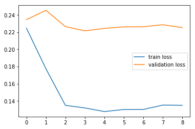

```
Training model on split # 1
Epoch: 1
Train set: Average loss: 0.1712, Accuracy: 60/140 (43%)
Validation set: Average loss: 0.3571, Accuracy: 4/20 (20%)
New best model built
Epoch: 2
Train set: Average loss: 0.1250, Accuracy: 82/140 (59%)
Validation set: Average loss: 0.1868, Accuracy: 4/20 (20%)
New best model built
Epoch: 3
Train set: Average loss: 0.0973, Accuracy: 109/140 (78%)
Validation set: Average loss: 0.1867, Accuracy: 7/20 (35%)
New best model built
Epoch: 4
Train set: Average loss: 0.0940, Accuracy: 106/140 (76%)
Validation set: Average loss: 0.1880, Accuracy: 7/20 (35%)
Epoch: 5
Train set: Average loss: 0.0901, Accuracy: 111/140 (79%)
Validation set: Average loss: 0.1850, Accuracy: 7/20 (35%)
New best model built
Epoch: 6
Train set: Average loss: 0.0859, Accuracy: 116/140 (83%)
Validation set: Average loss: 0.1837, Accuracy: 7/20 (35%)
New best model built
Epoch: 7
Train set: Average loss: 0.0943, Accuracy: 107/140 (76%)
Validation set: Average loss: 0.1861, Accuracy: 6/20 (30%)
Epoch: 8
Train set: Average loss: 0.0993, Accuracy: 100/140 (71%)
Validation set: Average loss: 0.1856, Accuracy: 7/20 (35%)
Epoch: 9
Train set: Average loss: 0.0878, Accuracy: 109/140 (78%)
Validation set: Average loss: 0.1867, Accuracy: 7/20 (35%)
Epoch: 10
Train set: Average loss: 0.0941, Accuracy: 103/140 (74%)
Validation set: Average loss: 0.1879, Accuracy: 7/20 (35%)
```

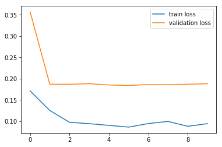

```
Training model on split # 2
Epoch: 1
Train set: Average loss: 0.1420, Accuracy: 71/140 (51%)
Validation set: Average loss: 0.7180, Accuracy: 3/20 (15%)
New best model built
Epoch: 2
Train set: Average loss: 0.1037, Accuracy: 91/140 (65%)
Validation set: Average loss: 0.1402, Accuracy: 12/20 (60%)
New best model built
Epoch: 3
Train set: Average loss: 0.0614, Accuracy: 126/140 (90%)
Validation set: Average loss: 0.1374, Accuracy: 10/20 (50%)
New best model built
Epoch: 4
Train set: Average loss: 0.0570, Accuracy: 127/140 (91%)
Validation set: Average loss: 0.1374, Accuracy: 10/20 (50%)
Epoch: 5
Train set: Average loss: 0.0595, Accuracy: 127/140 (91%)
Validation set: Average loss: 0.1368, Accuracy: 10/20 (50%)
New best model built
Epoch: 6
Train set: Average loss: 0.0603, Accuracy: 126/140 (90%)
Validation set: Average loss: 0.1361, Accuracy: 10/20 (50%)
New best model built
Epoch: 7
Train set: Average loss: 0.0557, Accuracy: 127/140 (91%)
Validation set: Average loss: 0.1351, Accuracy: 11/20 (55%)
New best model built
Epoch: 8
Train set: Average loss: 0.0578, Accuracy: 127/140 (91%)
Validation set: Average loss: 0.1371, Accuracy: 11/20 (55%)
Epoch: 9
Train set: Average loss: 0.0633, Accuracy: 123/140 (88%)
Validation set: Average loss: 0.1342, Accuracy: 11/20 (55%)
New best model built
Epoch: 10
Train set: Average loss: 0.0592, Accuracy: 125/140 (89%)
Validation set: Average loss: 0.1388, Accuracy: 10/20 (50%)
```

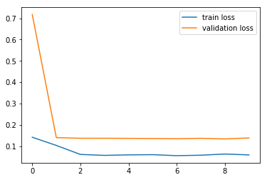

```
Training model on split # 3
Epoch: 1
Train set: Average loss: 0.1023, Accuracy: 89/140 (64%)
Validation set: Average loss: 0.2307, Accuracy: 4/20 (20%)
New best model built
Epoch: 2
Train set: Average loss: 0.0766, Accuracy: 107/140 (76%)
Validation set: Average loss: 0.1115, Accuracy: 12/20 (60%)
New best model built
Epoch: 3
Train set: Average loss: 0.0485, Accuracy: 125/140 (89%)
Validation set: Average loss: 0.1017, Accuracy: 12/20 (60%)
New best model built
Epoch: 4
Train set: Average loss: 0.0467, Accuracy: 124/140 (89%)
Validation set: Average loss: 0.0997, Accuracy: 13/20 (65%)
New best model built
Epoch: 5
Train set: Average loss: 0.0441, Accuracy: 125/140 (89%)
Validation set: Average loss: 0.0994, Accuracy: 13/20 (65%)
New best model built
Epoch: 6
Train set: Average loss: 0.0452, Accuracy: 121/140 (86%)
Validation set: Average loss: 0.0983, Accuracy: 13/20 (65%)
New best model built
Epoch: 7
Train set: Average loss: 0.0483, Accuracy: 123/140 (88%)
Validation set: Average loss: 0.0979, Accuracy: 14/20 (70%)
New best model built
Epoch: 8
Train set: Average loss: 0.0459, Accuracy: 125/140 (89%)
Validation set: Average loss: 0.1003, Accuracy: 13/20 (65%)
Epoch: 9
Train set: Average loss: 0.0451, Accuracy: 123/140 (88%)
Validation set: Average loss: 0.0981, Accuracy: 14/20 (70%)
Epoch: 10
Train set: Average loss: 0.0478, Accuracy: 126/140 (90%)
Validation set: Average loss: 0.0987, Accuracy: 13/20 (65%)
```

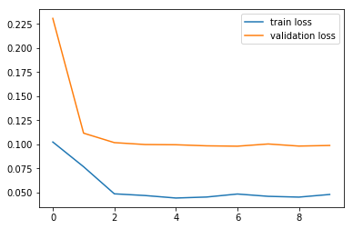

```
Training model on split # 4
Epoch: 1
Train set: Average loss: 0.0791, Accuracy: 108/140 (77%)
Validation set: Average loss: 0.3654, Accuracy: 6/20 (30%)
New best model built
Epoch: 2
Train set: Average loss: 0.0532, Accuracy: 122/140 (87%)
Validation set: Average loss: 0.1207, Accuracy: 11/20 (55%)
New best model built
Epoch: 3
Train set: Average loss: 0.0351, Accuracy: 128/140 (91%)
Validation set: Average loss: 0.1042, Accuracy: 12/20 (60%)
New best model built
Epoch: 4
Train set: Average loss: 0.0286, Accuracy: 134/140 (96%)
Validation set: Average loss: 0.1015, Accuracy: 13/20 (65%)
New best model built
Epoch: 5
Train set: Average loss: 0.0285, Accuracy: 133/140 (95%)
Validation set: Average loss: 0.0998, Accuracy: 13/20 (65%)
New best model built
Epoch: 6
Train set: Average loss: 0.0264, Accuracy: 133/140 (95%)
Validation set: Average loss: 0.1001, Accuracy: 14/20 (70%)
Epoch: 7
Train set: Average loss: 0.0285, Accuracy: 134/140 (96%)
Validation set: Average loss: 0.0993, Accuracy: 14/20 (70%)
New best model built
Epoch: 8
Train set: Average loss: 0.0286, Accuracy: 133/140 (95%)
Validation set: Average loss: 0.1023, Accuracy: 12/20 (60%)
Epoch: 9
Train set: Average loss: 0.0295, Accuracy: 131/140 (94%)
Validation set: Average loss: 0.1038, Accuracy: 12/20 (60%)
Epoch: 10
Train set: Average loss: 0.0269, Accuracy: 136/140 (97%)
Validation set: Average loss: 0.0988, Accuracy: 14/20 (70%)
New best model built
```

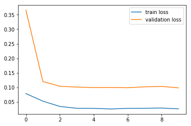

```
Evaluation on Train Set
Average loss: 0.0040, Accuracy: 91/100 (91%)
Evaluation on Test Set
Average loss: 0.0003, Accuracy: 2106/10000 (21%)
```

```python
resnet = ResNet18()
netClassifierEvaluation(resnet)
```

| #Model | Model | Number of epochs | Train accuracy | Test accuracy | Test accuracy on full data |
| --- | --- | --- | --- | --- | --- |
| A.1 | ResNet18 | 10 | 91% | 21% | 93.02% (+ with data augmentation) |

Sources for the last column : https://github.com/kuangliu/pytorch-cifar

## VGG-like architectures

**Question 4:** Same question as before, but with a *VGG*. Which model do you recommend?

```python
#I directly reused the implementation of VGG architecture from :
#https://github.com/kuangliu/pytorch-cifar/blob/master/models/resnet.py

cfg = {
    'VGG11': [64, 'M', 128, 'M', 256, 256, 'M', 512, 512, 'M', 512, 512, 'M'],
    'VGG13': [64, 64, 'M', 128, 128, 'M', 256, 256, 'M', 512, 512, 'M', 512, 512, 'M'],
    'VGG16': [64, 64, 'M', 128, 128, 'M', 256, 256, 256, 'M', 512, 512, 512, 'M', 512, 512, 512, 'M'],
    'VGG19': [64, 64, 'M', 128, 128, 'M', 256, 256, 256, 256, 'M', 512, 512, 512, 512, 'M', 512, 512, 512, 512, 'M'],
}


class VGG(nn.Module):
    def __init__(self, vgg_name):
        super(VGG, self).__init__()
        self.features = self._make_layers(cfg[vgg_name])
        self.classifier = nn.Linear(512, 10)

    def forward(self, x):
        out = self.features(x)
        out = out.view(out.size(0), -1)
        out = self.classifier(out)
        return out

    def _make_layers(self, cfg):
        layers = []
        in_channels = 3
        for x in cfg:
            if x == 'M':
                layers += [nn.MaxPool2d(kernel_size=2, stride=2)]
            else:
                layers += [nn.Conv2d(in_channels, x, kernel_size=3, padding=1),
                           nn.BatchNorm2d(x),
                           nn.ReLU(inplace=True)]
                in_channels = x
        layers += [nn.AvgPool2d(kernel_size=1, stride=1)]
        return nn.Sequential(*layers)
```

```
VGG11
Training model on split # 0
Epoch: 1
Train set: Average loss: 0.2404, Accuracy: 27/140 (19%)
Validation set: Average loss: 0.2357, Accuracy: 2/20 (10%)
New best model built
Epoch: 2
Train set: Average loss: 0.1753, Accuracy: 55/140 (39%)
Validation set: Average loss: 0.2520, Accuracy: 5/20 (25%)
Epoch: 3
Train set: Average loss: 0.1439, Accuracy: 77/140 (55%)
Validation set: Average loss: 0.2470, Accuracy: 4/20 (20%)
Epoch: 4
Train set: Average loss: 0.1425, Accuracy: 76/140 (54%)
Validation set: Average loss: 0.2520, Accuracy: 3/20 (15%)
Epoch: 5
Train set: Average loss: 0.1415, Accuracy: 68/140 (49%)
Validation set: Average loss: 0.2560, Accuracy: 3/20 (15%)
Epoch: 6
Train set: Average loss: 0.1455, Accuracy: 74/140 (53%)
Validation set: Average loss: 0.2589, Accuracy: 3/20 (15%)
Epoch: 7
Train set: Average loss: 0.1372, Accuracy: 81/140 (58%)
Validation set: Average loss: 0.2554, Accuracy: 3/20 (15%)
```

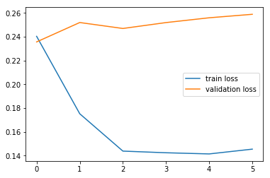

```
Training model on split # 1
Epoch: 1
Train set: Average loss: 0.2193, Accuracy: 37/140 (26%)
Validation set: Average loss: 0.2698, Accuracy: 6/20 (30%)
New best model built
Epoch: 2
Train set: Average loss: 0.1481, Accuracy: 71/140 (51%)
Validation set: Average loss: 0.1936, Accuracy: 8/20 (40%)
New best model built
Epoch: 3
Train set: Average loss: 0.1023, Accuracy: 99/140 (71%)
Validation set: Average loss: 0.1944, Accuracy: 8/20 (40%)
Epoch: 4
Train set: Average loss: 0.1076, Accuracy: 91/140 (65%)
Validation set: Average loss: 0.1962, Accuracy: 8/20 (40%)
Epoch: 5
Train set: Average loss: 0.1059, Accuracy: 89/140 (64%)
Validation set: Average loss: 0.1968, Accuracy: 9/20 (45%)
Epoch: 6
Train set: Average loss: 0.1045, Accuracy: 99/140 (71%)
Validation set: Average loss: 0.1965, Accuracy: 8/20 (40%)
Epoch: 7
Train set: Average loss: 0.1045, Accuracy: 98/140 (70%)
Validation set: Average loss: 0.1971, Accuracy: 9/20 (45%)
Epoch: 8
Train set: Average loss: 0.1011, Accuracy: 99/140 (71%)
Validation set: Average loss: 0.1964, Accuracy: 8/20 (40%)
```

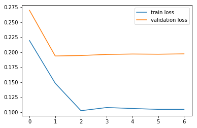

```
Training model on split # 2
Epoch: 1
Train set: Average loss: 0.1651, Accuracy: 67/140 (48%)
Validation set: Average loss: 0.3045, Accuracy: 8/20 (40%)
New best model built
Epoch: 2
Train set: Average loss: 0.1298, Accuracy: 68/140 (49%)
Validation set: Average loss: 0.1414, Accuracy: 11/20 (55%)
New best model built
Epoch: 3
Train set: Average loss: 0.0649, Accuracy: 116/140 (83%)
Validation set: Average loss: 0.1405, Accuracy: 10/20 (50%)
New best model built
Epoch: 4
Train set: Average loss: 0.0663, Accuracy: 118/140 (84%)
Validation set: Average loss: 0.1420, Accuracy: 9/20 (45%)
Epoch: 5
Train set: Average loss: 0.0652, Accuracy: 117/140 (84%)
Validation set: Average loss: 0.1405, Accuracy: 9/20 (45%)
New best model built
Epoch: 6
Train set: Average loss: 0.0693, Accuracy: 115/140 (82%)
Validation set: Average loss: 0.1378, Accuracy: 10/20 (50%)
New best model built
Epoch: 7
Train set: Average loss: 0.0622, Accuracy: 122/140 (87%)
Validation set: Average loss: 0.1381, Accuracy: 10/20 (50%)
Epoch: 8
Train set: Average loss: 0.0715, Accuracy: 107/140 (76%)
Validation set: Average loss: 0.1359, Accuracy: 10/20 (50%)
New best model built
Epoch: 9
Train set: Average loss: 0.0681, Accuracy: 115/140 (82%)
Validation set: Average loss: 0.1385, Accuracy: 10/20 (50%)
Epoch: 10
Train set: Average loss: 0.0671, Accuracy: 113/140 (81%)
Validation set: Average loss: 0.1361, Accuracy: 10/20 (50%)
```

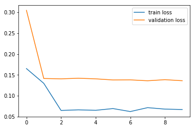

```
Training model on split # 3
Epoch: 1
Train set: Average loss: 0.1061, Accuracy: 90/140 (64%)
Validation set: Average loss: 0.0989, Accuracy: 14/20 (70%)
New best model built
Epoch: 2
Train set: Average loss: 0.0706, Accuracy: 112/140 (80%)
Validation set: Average loss: 0.0789, Accuracy: 13/20 (65%)
New best model built
Epoch: 3
Train set: Average loss: 0.0426, Accuracy: 128/140 (91%)
Validation set: Average loss: 0.0764, Accuracy: 14/20 (70%)
New best model built
Epoch: 4
Train set: Average loss: 0.0434, Accuracy: 125/140 (89%)
Validation set: Average loss: 0.0760, Accuracy: 13/20 (65%)
New best model built
Epoch: 5
Train set: Average loss: 0.0380, Accuracy: 129/140 (92%)
Validation set: Average loss: 0.0747, Accuracy: 14/20 (70%)
New best model built
Epoch: 6
Train set: Average loss: 0.0398, Accuracy: 133/140 (95%)
Validation set: Average loss: 0.0763, Accuracy: 13/20 (65%)
Epoch: 7
Train set: Average loss: 0.0401, Accuracy: 128/140 (91%)
Validation set: Average loss: 0.0757, Accuracy: 13/20 (65%)
Epoch: 8
Train set: Average loss: 0.0407, Accuracy: 127/140 (91%)
Validation set: Average loss: 0.0759, Accuracy: 13/20 (65%)
Epoch: 9
Train set: Average loss: 0.0435, Accuracy: 126/140 (90%)
Validation set: Average loss: 0.0752, Accuracy: 14/20 (70%)
Epoch: 10
Train set: Average loss: 0.0462, Accuracy: 123/140 (88%)
Validation set: Average loss: 0.0744, Accuracy: 13/20 (65%)
New best model built
```

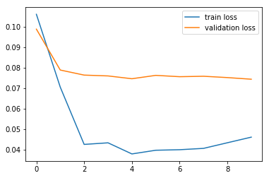

```
Training model on split # 4
Epoch: 1
Train set: Average loss: 0.0823, Accuracy: 99/140 (71%)
Validation set: Average loss: 0.3546, Accuracy: 6/20 (30%)
New best model built
Epoch: 2
Train set: Average loss: 0.0839, Accuracy: 101/140 (72%)
Validation set: Average loss: 0.1079, Accuracy: 13/20 (65%)
New best model built
Epoch: 3
Train set: Average loss: 0.0293, Accuracy: 135/140 (96%)
Validation set: Average loss: 0.1083, Accuracy: 13/20 (65%)
Epoch: 4
Train set: Average loss: 0.0289, Accuracy: 134/140 (96%)
Validation set: Average loss: 0.1087, Accuracy: 13/20 (65%)
Epoch: 5
Train set: Average loss: 0.0293, Accuracy: 132/140 (94%)
Validation set: Average loss: 0.1090, Accuracy: 13/20 (65%)
Epoch: 6
Train set: Average loss: 0.0278, Accuracy: 133/140 (95%)
Validation set: Average loss: 0.1073, Accuracy: 13/20 (65%)
New best model built
Epoch: 7
Train set: Average loss: 0.0285, Accuracy: 135/140 (96%)
Validation set: Average loss: 0.1076, Accuracy: 13/20 (65%)
Epoch: 8
Train set: Average loss: 0.0272, Accuracy: 134/140 (96%)
Validation set: Average loss: 0.1077, Accuracy: 13/20 (65%)
Epoch: 9
Train set: Average loss: 0.0252, Accuracy: 138/140 (99%)
Validation set: Average loss: 0.1082, Accuracy: 13/20 (65%)
Epoch: 10
Train set: Average loss: 0.0281, Accuracy: 135/140 (96%)
Validation set: Average loss: 0.1077, Accuracy: 13/20 (65%)
```

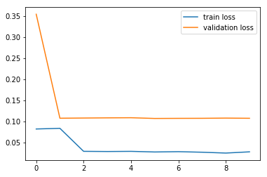

```
Evaluation on Train Set
Average loss: 0.0040, Accuracy: 91/100 (91%)
Evaluation on Test Set
Average loss: 0.0003, Accuracy: 2355/10000 (24%)
```

```python
for name_net in ['VGG11']: #,'VGG13','VGG16','VGG19']:
    print(name_net)
    vggnet = VGG(name_net)
    netClassifierEvaluation(vggnet)
    print("\n")

#I show the logs for one VGG only (if not we exceed 2MB in size)
```

| #Model | Model | Number of epochs | Train accuracy | Test accuracy | Test accuracy on full data |
| --- | --- | --- | --- | --- | --- |
| A.1 | ResNet18 | 10 | 91% | 21% | 93.02% (+ with data augmentation) |
| A.2 | VGG11 | 10 | 91% | 24% | XXX |
| A.3 | VGG13 | 10 | 69% | 22% | XXX |
| A.4 | VGG16 | 10 | 15% | 11% | 92.64% (+ with data augmentation) |
| A.5 | VGG19 | 10 | 15% | 13% | XXX |

Sources for the last column : https://github.com/kuangliu/pytorch-cifar for A.1. and A.4.

# Transfer learning

We propose to use pre-trained models on a classification and generative task, in order to improve the results of our setting.

## ImageNet features

Now, we will use some pre-trained models on ImageNet and see how well they compare on CIFAR. A list is available on: https://pytorch.org/docs/stable/torchvision/models.html.

**Question 5:** Pick a model from the list above, adapt it to CIFAR and retrain its final layer (or a block of layers, depending on the resources to which you have access to). Report its accuracy.

```python
#I created a class implementing a partially modified ResNet model, pre_trained, and
#with the last layer output dimension set up to the desired number of classes (10)
#The initializer has a finetuning parameter, which, if set to True, enables to finetune the weights of
#the 4 last ResNet blocks (8 layers)

class pretrainedResnet18(nn.Module):
    # implements a partially modified ResNet model
    # last layer output dimension has been set up to the desired number of classes (10)

    def __init__(self, fine_tuning=False):

        # we load pre-trained weights of the residual network
        # fine_tuning : boolean set to True if we want to fine-tune the highest layers
        #  (the number of highest fine-tuned layers is set as large as my memory could allow)

        super(pretrainedResnet18, self).__init__()

        self.resnet = models.resnet18(pretrained=True)

        # modify output dimension of last layer
        nb_input_features = self.resnet.fc.in_features
        self.resnet.fc = nn.Linear(nb_input_features, 10)

        if fine_tuning:
                # freezing all weights except 4 last ResNet blocks (8 layers) and last linear layer
                # print([m for m in self.resnet.modules()][0])

                for param in self.resnet.parameters():
                    param.requires_grad = False

                for param in self.resnet.fc.parameters():
                    param.requires_grad = True

                for (idx_child, child) in enumerate(self.resnet.children()):
                    if (idx_child == 6) or (idx_child == 7):  # module 3 and 4 (4 last ResNet blocks)
                        # print("ftuned", [param.size() for param in child.parameters()])
                        for param in child.parameters():
                            param.requires_grad = True

        else:
            # freezing all weights except last linear layer
            for param in self.resnet.parameters():
                param.requires_grad = False

            for param in self.resnet.fc.parameters():
                param.requires_grad = True

    def forward(self, x):
        return self.resnet.forward(x)
```

```
Training model on split # 0
Epoch: 1
Train set: Average loss: 0.2578, Accuracy: 27/140 (19%)
Validation set: Average loss: 0.3334, Accuracy: 2/20 (10%)
New best model built
Epoch: 2
Train set: Average loss: 0.0920, Accuracy: 107/140 (76%)
Validation set: Average loss: 0.2017, Accuracy: 5/20 (25%)
New best model built
Epoch: 3
Train set: Average loss: 0.0694, Accuracy: 122/140 (87%)
Validation set: Average loss: 0.2049, Accuracy: 4/20 (20%)
Epoch: 4
Train set: Average loss: 0.0726, Accuracy: 120/140 (86%)
Validation set: Average loss: 0.2020, Accuracy: 5/20 (25%)
Epoch: 5
Train set: Average loss: 0.0704, Accuracy: 123/140 (88%)
Validation set: Average loss: 0.2028, Accuracy: 5/20 (25%)
Epoch: 6
Train set: Average loss: 0.0702, Accuracy: 122/140 (87%)
Validation set: Average loss: 0.2037, Accuracy: 6/20 (30%)
Epoch: 7
Train set: Average loss: 0.0704, Accuracy: 123/140 (88%)
Validation set: Average loss: 0.2037, Accuracy: 5/20 (25%)
Epoch: 8
Train set: Average loss: 0.0763, Accuracy: 121/140 (86%)
Validation set: Average loss: 0.2022, Accuracy: 5/20 (25%)
```

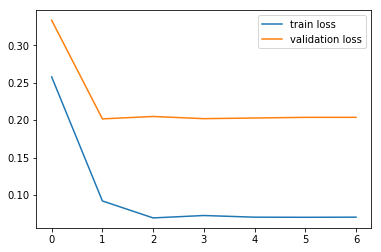

```
Training model on split # 1
Epoch: 1
Train set: Average loss: 0.1185, Accuracy: 89/140 (64%)
Validation set: Average loss: 0.1470, Accuracy: 11/20 (55%)
New best model built
Epoch: 2
Train set: Average loss: 0.0698, Accuracy: 116/140 (83%)
Validation set: Average loss: 0.0929, Accuracy: 13/20 (65%)
New best model built
Epoch: 3
Train set: Average loss: 0.0486, Accuracy: 131/140 (94%)
Validation set: Average loss: 0.0924, Accuracy: 14/20 (70%)
New best model built
Epoch: 4
Train set: Average loss: 0.0378, Accuracy: 137/140 (98%)
Validation set: Average loss: 0.0939, Accuracy: 14/20 (70%)
Epoch: 5
Train set: Average loss: 0.0408, Accuracy: 133/140 (95%)
Validation set: Average loss: 0.0934, Accuracy: 14/20 (70%)
Epoch: 6
Train set: Average loss: 0.0400, Accuracy: 137/140 (98%)
Validation set: Average loss: 0.0936, Accuracy: 13/20 (65%)
Epoch: 7
Train set: Average loss: 0.0437, Accuracy: 130/140 (93%)
Validation set: Average loss: 0.0944, Accuracy: 14/20 (70%)
Epoch: 8
Train set: Average loss: 0.0420, Accuracy: 133/140 (95%)
Validation set: Average loss: 0.0925, Accuracy: 14/20 (70%)
Epoch: 9
Train set: Average loss: 0.0410, Accuracy: 133/140 (95%)
Validation set: Average loss: 0.0928, Accuracy: 14/20 (70%)
```

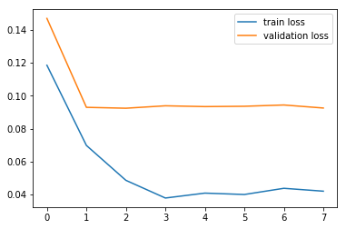

```
Training model on split # 2
Epoch: 1
Train set: Average loss: 0.0640, Accuracy: 116/140 (83%)
Validation set: Average loss: 0.0835, Accuracy: 14/20 (70%)
New best model built
Epoch: 2
Train set: Average loss: 0.0412, Accuracy: 127/140 (91%)
Validation set: Average loss: 0.0626, Accuracy: 16/20 (80%)
New best model built
Epoch: 3
Train set: Average loss: 0.0347, Accuracy: 130/140 (93%)
Validation set: Average loss: 0.0617, Accuracy: 16/20 (80%)
New best model built
Epoch: 4
Train set: Average loss: 0.0249, Accuracy: 136/140 (97%)
Validation set: Average loss: 0.0615, Accuracy: 16/20 (80%)
New best model built
Epoch: 5
Train set: Average loss: 0.0298, Accuracy: 136/140 (97%)
Validation set: Average loss: 0.0635, Accuracy: 16/20 (80%)
Epoch: 6
Train set: Average loss: 0.0304, Accuracy: 135/140 (96%)
Validation set: Average loss: 0.0610, Accuracy: 16/20 (80%)
New best model built
Epoch: 7
Train set: Average loss: 0.0282, Accuracy: 134/140 (96%)
Validation set: Average loss: 0.0622, Accuracy: 16/20 (80%)
Epoch: 8
Train set: Average loss: 0.0322, Accuracy: 136/140 (97%)
Validation set: Average loss: 0.0603, Accuracy: 16/20 (80%)
New best model built
Epoch: 9
Train set: Average loss: 0.0324, Accuracy: 134/140 (96%)
Validation set: Average loss: 0.0609, Accuracy: 16/20 (80%)
Epoch: 10
Train set: Average loss: 0.0278, Accuracy: 137/140 (98%)
Validation set: Average loss: 0.0637, Accuracy: 16/20 (80%)
```

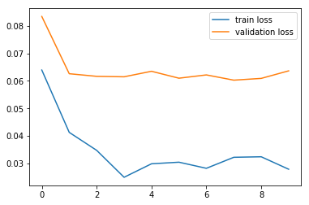

```
Training model on split # 3
Epoch: 1
Train set: Average loss: 0.0561, Accuracy: 117/140 (84%)
Validation set: Average loss: 0.0733, Accuracy: 17/20 (85%)
New best model built
Epoch: 2
Train set: Average loss: 0.0688, Accuracy: 116/140 (83%)
Validation set: Average loss: 0.0236, Accuracy: 19/20 (95%)
New best model built
Epoch: 3
Train set: Average loss: 0.0264, Accuracy: 133/140 (95%)
Validation set: Average loss: 0.0227, Accuracy: 19/20 (95%)
New best model built
Epoch: 4
Train set: Average loss: 0.0273, Accuracy: 131/140 (94%)
Validation set: Average loss: 0.0217, Accuracy: 19/20 (95%)
New best model built
Epoch: 5
Train set: Average loss: 0.0268, Accuracy: 135/140 (96%)
Validation set: Average loss: 0.0223, Accuracy: 19/20 (95%)
Epoch: 6
Train set: Average loss: 0.0290, Accuracy: 137/140 (98%)
Validation set: Average loss: 0.0227, Accuracy: 19/20 (95%)
Epoch: 7
Train set: Average loss: 0.0272, Accuracy: 135/140 (96%)
Validation set: Average loss: 0.0236, Accuracy: 19/20 (95%)
Epoch: 8
Train set: Average loss: 0.0243, Accuracy: 138/140 (99%)
Validation set: Average loss: 0.0231, Accuracy: 19/20 (95%)
Epoch: 9
Train set: Average loss: 0.0294, Accuracy: 133/140 (95%)
Validation set: Average loss: 0.0226, Accuracy: 19/20 (95%)
Epoch: 10
Train set: Average loss: 0.0279, Accuracy: 133/140 (95%)
Validation set: Average loss: 0.0209, Accuracy: 19/20 (95%)
New best model built
```

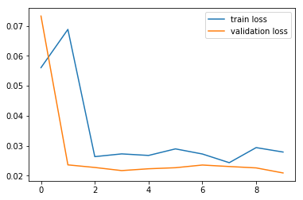

```
Training model on split # 4
Epoch: 1
Train set: Average loss: 0.0435, Accuracy: 127/140 (91%)
Validation set: Average loss: 0.0684, Accuracy: 17/20 (85%)
New best model built
Epoch: 2
Train set: Average loss: 0.0477, Accuracy: 122/140 (87%)
Validation set: Average loss: 0.0309, Accuracy: 19/20 (95%)
New best model built
Epoch: 3
Train set: Average loss: 0.0275, Accuracy: 127/140 (91%)
Validation set: Average loss: 0.0252, Accuracy: 19/20 (95%)
New best model built
Epoch: 4
Train set: Average loss: 0.0211, Accuracy: 134/140 (96%)
Validation set: Average loss: 0.0264, Accuracy: 19/20 (95%)
Epoch: 5
Train set: Average loss: 0.0241, Accuracy: 135/140 (96%)
Validation set: Average loss: 0.0254, Accuracy: 19/20 (95%)
Epoch: 6
Train set: Average loss: 0.0209, Accuracy: 136/140 (97%)
Validation set: Average loss: 0.0245, Accuracy: 19/20 (95%)
New best model built
Epoch: 7
Train set: Average loss: 0.0248, Accuracy: 135/140 (96%)
Validation set: Average loss: 0.0257, Accuracy: 19/20 (95%)
Epoch: 8
Train set: Average loss: 0.0241, Accuracy: 132/140 (94%)
Validation set: Average loss: 0.0236, Accuracy: 19/20 (95%)
New best model built
Epoch: 9
Train set: Average loss: 0.0198, Accuracy: 138/140 (99%)
Validation set: Average loss: 0.0239, Accuracy: 19/20 (95%)
Epoch: 10
Train set: Average loss: 0.0214, Accuracy: 135/140 (96%)
Validation set: Average loss: 0.0236, Accuracy: 19/20 (95%)
New best model built
```

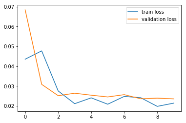

```
Evaluation on Train Set
Average loss: 0.0016, Accuracy: 98/100 (98%)
Evaluation on Test Set
Average loss: 0.0001, Accuracy: 5412/10000 (54%)
```

```python
pretrained_resnet18_no_finetuning = pretrainedResnet18(fine_tuning=False)
netClassifierEvaluation(pretrained_resnet18_no_finetuning, input_size=224)
```

```
Training model on split # 0
Epoch: 1
Train set: Average loss: 0.1929, Accuracy: 52/140 (37%)
Validation set: Average loss: 0.3270, Accuracy: 4/20 (20%)
New best model built
Epoch: 2
Train set: Average loss: 0.0361, Accuracy: 122/140 (87%)
Validation set: Average loss: 0.1811, Accuracy: 12/20 (60%)
New best model built
Epoch: 3
Train set: Average loss: 0.0149, Accuracy: 138/140 (99%)
Validation set: Average loss: 0.1797, Accuracy: 11/20 (55%)
New best model built
Epoch: 4
Train set: Average loss: 0.0159, Accuracy: 139/140 (99%)
Validation set: Average loss: 0.1772, Accuracy: 11/20 (55%)
New best model built
Epoch: 5
Train set: Average loss: 0.0137, Accuracy: 137/140 (98%)
Validation set: Average loss: 0.1772, Accuracy: 10/20 (50%)
New best model built
Epoch: 6
Train set: Average loss: 0.0154, Accuracy: 137/140 (98%)
Validation set: Average loss: 0.1748, Accuracy: 11/20 (55%)
New best model built
Epoch: 7
Train set: Average loss: 0.0155, Accuracy: 135/140 (96%)
Validation set: Average loss: 0.1750, Accuracy: 11/20 (55%)
Epoch: 8
Train set: Average loss: 0.0134, Accuracy: 136/140 (97%)
Validation set: Average loss: 0.1748, Accuracy: 11/20 (55%)
New best model built
Epoch: 9
Train set: Average loss: 0.0125, Accuracy: 139/140 (99%)
Validation set: Average loss: 0.1732, Accuracy: 11/20 (55%)
New best model built
Epoch: 10
Train set: Average loss: 0.0149, Accuracy: 138/140 (99%)
Validation set: Average loss: 0.1758, Accuracy: 11/20 (55%)
```

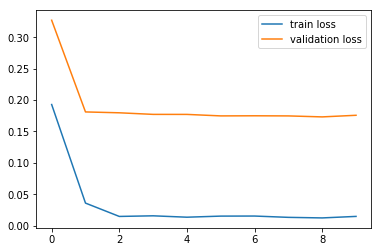

```
Training model on split # 1
Epoch: 1
Train set: Average loss: 0.0374, Accuracy: 127/140 (91%)
Validation set: Average loss: 0.0807, Accuracy: 15/20 (75%)
New best model built
Epoch: 2
Train set: Average loss: 0.0081, Accuracy: 137/140 (98%)
Validation set: Average loss: 0.0712, Accuracy: 15/20 (75%)
New best model built
Epoch: 3
Train set: Average loss: 0.0075, Accuracy: 139/140 (99%)
Validation set: Average loss: 0.0724, Accuracy: 15/20 (75%)
Epoch: 4
Train set: Average loss: 0.0047, Accuracy: 140/140 (100%)
Validation set: Average loss: 0.0734, Accuracy: 15/20 (75%)
Epoch: 5
Train set: Average loss: 0.0043, Accuracy: 139/140 (99%)
Validation set: Average loss: 0.0709, Accuracy: 15/20 (75%)
New best model built
Epoch: 6
Train set: Average loss: 0.0053, Accuracy: 139/140 (99%)
Validation set: Average loss: 0.0711, Accuracy: 16/20 (80%)
Epoch: 7
Train set: Average loss: 0.0057, Accuracy: 140/140 (100%)
Validation set: Average loss: 0.0718, Accuracy: 16/20 (80%)
Epoch: 8
Train set: Average loss: 0.0065, Accuracy: 139/140 (99%)
Validation set: Average loss: 0.0708, Accuracy: 15/20 (75%)
New best model built
Epoch: 9
Train set: Average loss: 0.0058, Accuracy: 139/140 (99%)
Validation set: Average loss: 0.0713, Accuracy: 15/20 (75%)
Epoch: 10
Train set: Average loss: 0.0045, Accuracy: 140/140 (100%)
Validation set: Average loss: 0.0714, Accuracy: 15/20 (75%)
```

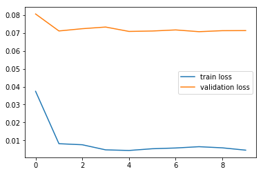

```
Training model on split # 2
Epoch: 1
Train set: Average loss: 0.0122, Accuracy: 136/140 (97%)
Validation set: Average loss: 0.0680, Accuracy: 17/20 (85%)
New best model built
Epoch: 2
Train set: Average loss: 0.0055, Accuracy: 138/140 (99%)
Validation set: Average loss: 0.0632, Accuracy: 17/20 (85%)
New best model built
Epoch: 3
Train set: Average loss: 0.0020, Accuracy: 140/140 (100%)
Validation set: Average loss: 0.0583, Accuracy: 17/20 (85%)
New best model built
Epoch: 4
Train set: Average loss: 0.0024, Accuracy: 140/140 (100%)
Validation set: Average loss: 0.0613, Accuracy: 17/20 (85%)
Epoch: 5
Train set: Average loss: 0.0026, Accuracy: 140/140 (100%)
Validation set: Average loss: 0.0622, Accuracy: 17/20 (85%)
Epoch: 6
Train set: Average loss: 0.0035, Accuracy: 140/140 (100%)
Validation set: Average loss: 0.0615, Accuracy: 17/20 (85%)
Epoch: 7
Train set: Average loss: 0.0034, Accuracy: 139/140 (99%)
Validation set: Average loss: 0.0627, Accuracy: 17/20 (85%)
Epoch: 8
Train set: Average loss: 0.0029, Accuracy: 140/140 (100%)
Validation set: Average loss: 0.0630, Accuracy: 17/20 (85%)
Epoch: 9
Train set: Average loss: 0.0036, Accuracy: 140/140 (100%)
Validation set: Average loss: 0.0647, Accuracy: 17/20 (85%)
```

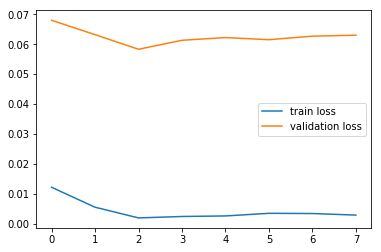

```
Training model on split # 3
Epoch: 1
Train set: Average loss: 0.0113, Accuracy: 136/140 (97%)
Validation set: Average loss: 0.0035, Accuracy: 20/20 (100%)
New best model built
Epoch: 2
Train set: Average loss: 0.0053, Accuracy: 137/140 (98%)
Validation set: Average loss: 0.0019, Accuracy: 20/20 (100%)
New best model built
Epoch: 3
Train set: Average loss: 0.0051, Accuracy: 138/140 (99%)
Validation set: Average loss: 0.0014, Accuracy: 20/20 (100%)
New best model built
Epoch: 4
Train set: Average loss: 0.0030, Accuracy: 139/140 (99%)
Validation set: Average loss: 0.0016, Accuracy: 20/20 (100%)
Epoch: 5
Train set: Average loss: 0.0046, Accuracy: 138/140 (99%)
Validation set: Average loss: 0.0016, Accuracy: 20/20 (100%)
Epoch: 6
Train set: Average loss: 0.0036, Accuracy: 140/140 (100%)
Validation set: Average loss: 0.0016, Accuracy: 20/20 (100%)
Epoch: 7
Train set: Average loss: 0.0057, Accuracy: 138/140 (99%)
Validation set: Average loss: 0.0013, Accuracy: 20/20 (100%)
New best model built
Epoch: 8
Train set: Average loss: 0.0029, Accuracy: 140/140 (100%)
Validation set: Average loss: 0.0015, Accuracy: 20/20 (100%)
Epoch: 9
Train set: Average loss: 0.0028, Accuracy: 140/140 (100%)
Validation set: Average loss: 0.0016, Accuracy: 20/20 (100%)
Epoch: 10
Train set: Average loss: 0.0045, Accuracy: 139/140 (99%)
Validation set: Average loss: 0.0015, Accuracy: 20/20 (100%)
```

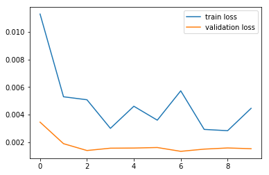

```
Training model on split # 4
Epoch: 1
Train set: Average loss: 0.0048, Accuracy: 137/140 (98%)
Validation set: Average loss: 0.0005, Accuracy: 20/20 (100%)
New best model built
Epoch: 2
Train set: Average loss: 0.0021, Accuracy: 140/140 (100%)
Validation set: Average loss: 0.0004, Accuracy: 20/20 (100%)
New best model built
Epoch: 3
Train set: Average loss: 0.0037, Accuracy: 139/140 (99%)
Validation set: Average loss: 0.0003, Accuracy: 20/20 (100%)
New best model built
Epoch: 4
Train set: Average loss: 0.0032, Accuracy: 139/140 (99%)
Validation set: Average loss: 0.0004, Accuracy: 20/20 (100%)
Epoch: 5
Train set: Average loss: 0.0020, Accuracy: 140/140 (100%)
Validation set: Average loss: 0.0004, Accuracy: 20/20 (100%)
Epoch: 6
Train set: Average loss: 0.0016, Accuracy: 140/140 (100%)
Validation set: Average loss: 0.0003, Accuracy: 20/20 (100%)
Epoch: 7
Train set: Average loss: 0.0021, Accuracy: 140/140 (100%)
Validation set: Average loss: 0.0004, Accuracy: 20/20 (100%)
Epoch: 8
Train set: Average loss: 0.0037, Accuracy: 138/140 (99%)
Validation set: Average loss: 0.0004, Accuracy: 20/20 (100%)
Epoch: 9
Train set: Average loss: 0.0019, Accuracy: 140/140 (100%)
Validation set: Average loss: 0.0004, Accuracy: 20/20 (100%)
```

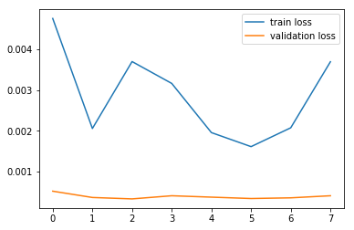

```
Evaluation on Train Set
Average loss: 0.0000, Accuracy: 100/100 (100%)
Evaluation on Test Set
Average loss: 0.0002, Accuracy: 5076/10000 (51%)
```

```python
pretrained_resnet18_finetuning = pretrainedResnet18(fine_tuning=True)
netClassifierEvaluation(pretrained_resnet18_finetuning, input_size=224)
```

| #Model | Model | Number of epochs | Train accuracy | Test accuracy | Test accuracy on full data |
| --- | --- | --- | --- | --- | --- |
| **A** | **TRAINING FROM SCRATCH** | ----- | ------ | ------ | ------ |
| A.1 | ResNet18 | 10 | 91% | 21% | 93.02% (+ with data augmentation) |
| **B** | **TRANSFER LEARNING** | ----- | ------ | ------ | ------ |
| B.1 | ResNet18 pretrained (no finetuning) | 10 | 98% | 54% | XXX |
| B.2 | ResNet18 pretrained (finetuning) | 10 | 100% | 51% | XXX |

## DCGan features

GANs correspond to an unsupervised technique for generating images. In https://arxiv.org/pdf/1511.06434.pdf, Sec. 5.1 shows that the representation obtained from the Discriminator has some nice generalization properties on CIFAR10.

**Question 6:** Using for instance a pretrained model from https://github.com/soumith/dcgan.torch combined with https://github.com/pytorch/examples/tree/master/dcgan, propose a model to train on $\mathcal{X}_{\text{train}}$. Train it and report its accuracy.

*Hint:* You can use the library: https://github.com/bshillingford/python-torchfile to load the weights of a model from torch(Lua) to pytorch(python).

```python
#1) I imported the implementation of Generator and Discriminator
#from https://github.com/csinva/pytorch_gan_pretrained/tree/master/cifar10_dcgan
#(implementation itself inspired from https://github.com/pytorch/examples/tree/master/dcgan)
#I chose this implementation as pre-trained network weights on CIFAR were saved in the repository

#2) Then I splitted the disciminator architecture into a features extractor part and a classifier part
#since we need to get the discriminator embeddings of the input data to build our classifier
#[This will require threfore some adaptations when loading the pre-trained network weights
#to make them compatible with the split in the model architecture]

manualSeed = random.randint(1, 10000)
random.seed(manualSeed)
torch.manual_seed(manualSeed)
cudnn.benchmark = True

def weights_init(m):
    # custom weights initialization called on netG and netD
    classname = m.__class__.__name__
    if classname.find('Conv') != -1:
        m.weight.data.normal_(0.0, 0.02)
    elif classname.find('BatchNorm') != -1:
        m.weight.data.normal_(1.0, 0.02)
        m.bias.data.fill_(0)

class Generator(nn.Module):
    def __init__(self, nc=3, nz=100, ngf=64):
        super(Generator, self).__init__()
        self.nz = nz
        self.main = nn.Sequential(
            # input is Z, going into a convolution
            nn.ConvTranspose2d(     nz, ngf * 8, 4, 1, 0, bias=False),
            nn.BatchNorm2d(ngf * 8),
            nn.ReLU(True),
            # state size. (ngf*8) x 4 x 4
            nn.ConvTranspose2d(ngf * 8, ngf * 4, 4, 2, 1, bias=False),
            nn.BatchNorm2d(ngf * 4),
            nn.ReLU(True),
            # state size. (ngf*4) x 8 x 8
            nn.ConvTranspose2d(ngf * 4, ngf * 2, 4, 2, 1, bias=False),
            nn.BatchNorm2d(ngf * 2),
            nn.ReLU(True),
            # state size. (ngf*2) x 16 x 16
            nn.ConvTranspose2d(ngf * 2,     ngf, 4, 2, 1, bias=False),
            nn.BatchNorm2d(ngf),
            nn.ReLU(True),
            nn.ConvTranspose2d(    ngf,      nc, kernel_size=1, stride=1, padding=0, bias=False),
            nn.Tanh()
        )

    def forward(self, input):
        output = self.main(input)
        return output

#I created an intermediary module DiscriminatorFeaturesExtractor
#to make it possible to get the discriminator embeddings of the input data

class DiscriminatorFeaturesExtractor(nn.Module):
    def __init__(self, nc=3, ndf=64):
        super(DiscriminatorFeaturesExtractor, self).__init__()
        self.main = nn.Sequential(
            # input is (nc) x 32 x 32
            nn.Conv2d(nc, ndf, 4, 2, 1, bias=False),
            nn.LeakyReLU(0.2, inplace=True),
            # state size. (ndf) x 16 x 16
            nn.Conv2d(ndf, ndf * 2, 4, 2, 1, bias=False),
            nn.BatchNorm2d(ndf * 2),
            nn.LeakyReLU(0.2, inplace=True),
            # state size. (ndf*2) x 8 x 8
            nn.Conv2d(ndf * 2, ndf * 4, 4, 2, 1, bias=False),
            nn.BatchNorm2d(ndf * 4),
            nn.LeakyReLU(0.2, inplace=True),
            # state size. (ndf*4) x 4 x 4
            nn.Conv2d(ndf * 4, ndf * 8, 4, 2, 1, bias=False),
            nn.BatchNorm2d(ndf * 8),
            nn.LeakyReLU(0.2, inplace=True),
            # state size. (ndf*8) x 2 x 2
        )

    def forward(self, input):
        output = self.main(input)
        return output

class Discriminator(nn.Module):
    def __init__(self, nc=3, ndf=64):
        super(Discriminator, self).__init__()
        self.ndf = ndf
        self.features_extractor = DiscriminatorFeaturesExtractor(nc,ndf).to(device)
        self.main = nn.Sequential(
            # state size. (ndf*8) x 2 x 2
            nn.Conv2d(ndf * 8, 1, 2, 2, 0, bias=False),
            nn.Sigmoid()
        )

    def forward(self, input):
        features = self.features_extractor(input)
        output = self.main(features)
        res = output.view(-1, 1).squeeze(1)
        return res
```

```python
#On the basis of code I imported from https://github.com/pytorch/examples/tree/master/dcgan,
#I created a class enabling to train a GAN with train+val sets and assess on a test set the performance of an SVM
#classifier on the top of the GAN Discriminator embeddings
#Its initialize method takes in input
#-transform_train, transform_test : how we process the data from trainDataSet and valDataSet for network input
#-netG, netD : the Generator and Discriminator Network of the GAN
#-nb_epochs, patience, batch_size, lr : parameters of the ADAM optimizer

#Two options are possible :
#Option 1 :  we use a proportion of train unlabelled dataset to train the GAN
#Option 2 : we use weights of a GAN pre-trained on CIFAR training dataset
#Important note : to be able to run this option,
#one need to download the two files "netG_epoch_199.pth","netD_epoch_199.pth" in the following Git repository :
#https://github.com/csinva/pytorch_gan_pretrained/tree/master/cifar10_dcgan/weights
#and to put the two files in a folder named "GAN_weights"

class GAN_SVM_EvaluationObject():

    def __init__(self, dataset_train, dataset_val, transform_train, transform_test, netG, netD, nb_epochs = 200, patience = 10,
                 batch_size=10, lr=0.0002, shuffle_train=True, shuffle_val=False):

        # Pytorch data loaders
        # we will use train and validation dataset to train the SVM on the top of GAN representation
        dataset_train.transform = transform_train
        self.train_loader = torch.utils.data.DataLoader(dataset_train, batch_size=batch_size,
                                                        shuffle=shuffle_train, num_workers=1)
        dataset_val.transform = transform_test
        self.val_loader = torch.utils.data.DataLoader(dataset_val, batch_size=batch_size,
                                                      shuffle=shuffle_val, num_workers=1)
        self.transform_train = transform_train
        self.transform_test = transform_test
        self.batch_size = batch_size

        #Network
        self.netG = netG
        self.netD = netD
        if use_cuda: self.netG = self.netG.cuda()
        if use_cuda: self.netD = self.netD.cuda()
        self.criterion = nn.BCELoss()

        #Optimizer
        self.optimizerD = optim.Adam(netD.parameters(), lr=lr, betas=(0.5, 0.999))
        self.optimizerG = optim.Adam(netG.parameters(), lr=lr, betas=(0.5, 0.999))

        self.nb_epochs = nb_epochs
        self.patience = patience

    def train_GAN(self, dataset, viz=False):
        #learn the weights of the GAN with data from dataset

        dataset.transform = self.transform_train
        loader = torch.utils.data.DataLoader(dataset, batch_size=self.batch_size,
                                                      shuffle=True, num_workers=1)

        self.netG.apply(weights_init)
        self.netD.apply(weights_init)

        nz = self.netG.nz

        fixed_noise = torch.randn(self.batch_size, nz, 1, 1, device=device)
        real_label = 1
        fake_label = 0

        history_disc_loss = np.zeros(self.nb_epochs)
        history_gen_loss = np.zeros(self.nb_epochs)

        for epoch in range(self.nb_epochs):

            disc_loss = 0
            gen_loss = 0

            total = 0

            for i, (data, targets) in enumerate(loader):
            #for i, data in enumerate(loader, 0):
                ############################
                # (1) Update D network: maximize log(D(x)) + log(1 - D(G(z)))
                ###########################
                # train with real
                self.netD.zero_grad()
                real_cpu = data.to(device)
                batch_size = real_cpu.size(0)
                label = torch.full((batch_size,), real_label, device=device)
                output = self.netD(real_cpu)
                errD_real = self.criterion(output, label)
                errD_real.backward()
                D_x = output.mean().item()

                # train with fake
                noise = torch.randn(batch_size, nz, 1, 1, device=device)
                fake = self.netG(noise)
                label.fill_(fake_label)
                output = self.netD(fake.detach())
                errD_fake = self.criterion(output, label)
                errD_fake.backward()
                D_G_z1 = output.mean().item()
                errD = errD_real + errD_fake
                disc_loss += errD.item()
                self.optimizerD.step()

                ############################
                # (2) Update G network: maximize log(D(G(z)))
                ###########################
                self.netG.zero_grad()
                label.fill_(real_label)  # fake labels are real for generator cost
                output = self.netD(fake)
                errG = self.criterion(output, label)
                errG.backward()
                gen_loss += errG.item()
                D_G_z2 = output.mean().item()
                self.optimizerG.step()

                total += 1
                print(data.shape)

                print('[%d/%d][%d/%d] Loss_D: %.4f Loss_G: %.4f D(x): %.4f D(G(z)): %.4f / %.4f'
                      % (epoch,self.nb_epochs, i, len(loader),
                         errD.item(), errG.item(), D_x, D_G_z1, D_G_z2))

            history_disc_loss[epoch] = disc_loss / total
            history_gen_loss[epoch] = gen_loss / total

            # do checkpointing
            torch.save(self.netG.state_dict(), '%s/netG_epoch_%d.pth' % ('checkpoint', epoch))
            torch.save(self.netD.state_dict(), '%s/netD_epoch_%d.pth' % ('checkpoint', epoch))

            #viz gen and disc errors
            if viz:
                if (epoch>1) and (epoch%5==0):
                    plt.plot(np.arange(epoch),history_disc_loss[:epoch]);
                    plt.xlabel("iterations"); plt.ylabel("discriminator loss"); plt.show()
                    plt.plot(np.arange(epoch),history_gen_loss[:epoch]);
                    plt.xlabel("iterations"); plt.ylabel("generator loss"); plt.show()

    def load_weights_GAN(self, pathG, pathD):
        #load the weights of the GAN from files pathG and pathD

        weightsG = torch.load(pathG)
        self.netG.load_state_dict(weightsG)

        weightsD = torch.load(pathD) #print(weightsD.keys())
        #we need to change the keys of the weights dictionnary to load the discriminator weights
        #indeed we splitted the disciminator architecture into a features extractor part and a classifier part
        #since we need to get the discriminator embeddings of the net input data
        weightsD_new = {}
        for (name,weights) in weightsD.items():
            if name!='main.11.weight':
                new_name = 'features_extractor.'+name
                weightsD_new[new_name] = weights
            else:
                weightsD_new['main.0.weight'] = weights
        weightsD = weightsD_new
        self.netD.load_state_dict(weightsD)

    def get_GAN_embeddings(self, loader):
        #get the GAN discriminator embeddings of data loaded from loader

        size_embedding = (self.netD.ndf*8) * 2 * 2
        nb = len(loader)*self.batch_size
        embeddings = np.zeros((nb, size_embedding))
        labels = np.zeros(nb)
        idx = 0
        with torch.no_grad():
            for batch_idx, (inputs, targets) in enumerate(loader):
                inputs = inputs.to(device)
                feats =  self.netD.features_extractor(inputs)
                if use_cuda: feats = feats.cpu()
                feats = feats.data.numpy()
                embeddings[idx:idx+self.batch_size,:] = feats.reshape((self.batch_size,size_embedding))
                tmp = targets
                if use_cuda: tmp = tmp.cpu()
                labels[idx:idx+self.batch_size] = tmp.data.numpy()
                idx += self.batch_size
        return embeddings, labels

    def train_SVM(self, C=None, viz_embeddings=False, viz=False):
        #train a SVM on the GAN embeddings of training labelled data + unlabelled data

        #A. Computing GAN discriminator embeddings of train and validation data
        embeddings_train, targets_train = self.get_GAN_embeddings(self.train_loader)
        embeddings_val, targets_val = self.get_GAN_embeddings(self.val_loader)

        #B. Training SVM, with C hyperparameter selection on validation set (C = regularization weight)
        if C is None:
            list_C = [pow(10,i) for i in range(-6,2)]
            scores = []
            for C in list_C:
                svm = SVC(C=C,
                          kernel='linear',
                          decision_function_shape='ovr',
                          class_weight = 'balanced',
                          random_state = 42)
                svm.fit(embeddings_train, targets_train)
                scores.append(svm.score(embeddings_val, targets_val))
            if viz:
                plt.semilogx()
                plt.scatter(list_C,scores)
                plt.xlabel("C (SVM hyperparameter)"); plt.ylabel("validation score")
                plt.show()
            C = list_C[np.argmax(scores)]
            if viz: print("Selected C",C)

        self.svm = SVC(C=C,
                  kernel='linear',
                  class_weight = 'balanced',
                  random_state = 42)
        self.svm.fit(embeddings_train, targets_train)

        correct = np.sum(self.svm.predict(embeddings_train)==targets_train)
        total = targets_train.shape[0]
        acc = 100. * correct / total
        print('Train set: Accuracy: {}/{} ({:.0f}%)'.format(correct, total, acc))
        correct = np.sum(self.svm.predict(embeddings_val)==targets_val)
        total = targets_val.shape[0]
        acc = 100. * correct / total
        print('Validation set: Accuracy: {}/{} ({:.0f}%)'.format(correct, total, acc))

    def test_eval(self, testDataSet):
        #assess the predictions of the SVM on data from testDataSet

        #A. Computing GAN discriminator embeddings of test data
        testDataSet.transform = self.transform_test
        test_loader = torch.utils.data.DataLoader(testDataSet, batch_size=self.batch_size, shuffle=False, num_workers=1)
        embeddings_test, targets =  self.get_GAN_embeddings(test_loader)

        #B. Assessing the GAN-SVM selection on the test set
        predictions = self.svm.predict(embeddings_test)
        correct = np.sum(predictions==targets)
        total = targets.shape[0]
        acc = 100. * correct / total
        print('Test set: Accuracy: {}/{} ({:.0f}%)'.format(correct, total, acc))


def GAN_SVM_Evaluation(pretrained_GAN=False):

    dataset_train, dataset_val = trainValDatasets[0] #building a unique model based on first split 80/20

    input_size = 32
    transform = transforms.Compose([
        transforms.Resize((input_size,input_size)),
        transforms.ToTensor(),
        transforms.Normalize((0.4914, 0.4822, 0.4465), (0.2023, 0.1994, 0.2010)),
    ])

    transform_train = transform
    transform_test = transform

    netG = Generator(nc=3, nz=100, ngf=64).to(device)
    netD = Discriminator(nc=3, ndf=64).to(device)

    net_eval = GAN_SVM_EvaluationObject(dataset_train, dataset_val, transform_train, transform_test, netG, netD,
                                     nb_epochs = 10, patience = 5, batch_size=10, lr=0.01)

    if pretrained_GAN:
         # we use weights of a GAN pre-trained on CIFAR training dataset
        net_eval.load_weights_GAN("GAN_weights/netG_epoch_199.pth","GAN_weights/netD_epoch_199.pth")
    else:
         # we use a proportion of train unlabelled dataset to train the GAN (here 5000)
        subsetUnlabelledDataSet  = CIFAR10("./", known_targets = False, download=False, train=True,
                                           min_idx_images = 0, nb_images =  5000)
        net_eval.train_GAN(subsetUnlabelledDataSet, viz=True)

    net_eval.train_SVM(C=None,viz=True)
    net_eval.test_eval(testDataSet)
```

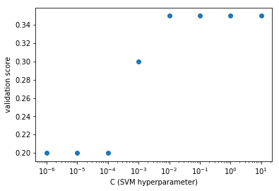

```
Selected C 0.01
Train set: Accuracy: 140/140 (100%)
Validation set: Accuracy: 7/20 (35%)
Test set: Accuracy: 3032/10000 (30%)
```

```python
#Two options are possible :
#Option 1 :  we use a proportion of train unlabelled dataset to train the GAN
#Option 2 : we use weights of a GAN pre-trained on CIFAR training dataset
#Important note : to be able to run this option,
#one need to download the two files "netG_epoch_199.pth","netD_epoch_199.pth" in the following Git repository :
#https://github.com/csinva/pytorch_gan_pretrained/tree/master/cifar10_dcgan/weights
#and to put the two files in a folder named "GAN_weights"

#Option 1
#GAN_SVM_Evaluation(pretrained_GAN=False)

#Option 2
GAN_SVM_Evaluation(pretrained_GAN=True)
```

| #Model | Model | Number of epochs* | Train accuracy | Test accuracy | Test accuracy on full data *** |
| --- | --- | --- | --- | --- | --- |
| **A** | **TRAINING FROM SCRATCH** | ----- | ------ | ------ | ------ |
| A.1 | ResNet18 | 10 | 91% | 21% | 93.02% (+ with data augmentation) |
| **B** | **TRANSFER LEARNING** | ----- | ------ | ------ | ------ |
| B.2 | ResNet18 pretrained (finetuning) | 10 | 100% | 51% | XXX |
| **C** | **SEMI-SUPERVISED LEARNING** | ----- | ------ | ------ | ------ |
| C.1 | GAN pretrained + SVM | Not adequate (pre-training) | 100% | 30% | 82.8% |

( *** ) Sources for the last column :

- https://github.com/kuangliu/pytorch-cifar for A.1
- https://arxiv.org/pdf/1703.08961.pdf for C.1.

# Incorporating *a priori*

Geometrical *a priori* are appealing for image classification tasks. For now, we only consider linear transformations $\mathcal{T}$ of the inputs $x:\mathbb{S}^2\rightarrow\mathbb{R}$ where $\mathbb{S}$ is the support of an image, meaning that:

$$\forall u\in\mathbb{S}^2,\mathcal{T}(\lambda x+\mu y)(u)=\lambda \mathcal{T}(x)(u)+\mu \mathcal{T}(y)(u)\,.$$

For instance if an image had an infinite support, a translation $\mathcal{T}_a$ by $a$ would lead to:

$$\forall u, \mathcal{T}_a(x)(u)=x(u-a)\,.$$

Otherwise, one has to handle several boundary effects.

**Question 7:** Explain the issues when dealing with translations, rotations, scaling effects, color changes on $32\times32$ images. Propose several ideas to tackle them.

> One specificity we need to account for, when considering data augmentation with geometric transformations, is that we are working with very small images. Below, the consequences for the various tranformation types:

> Translation and scaling effects : We should be careful not to miss a large part of the featured object when translating or zooming. We could for instance limit the translation vector to a few pixels (or constrain the scaling to include the center of the image) as well as the scaling factor. Performing both zoom and translation is also a way to avoid the risk that the network would use the padding frontiers as features for classification.

> Rotation : If we allow for rotation of 45° for instance, as the image input size is fixed to 32, we would need either to keep only the central zone of the rotated image, or to dezoom and padd a large proportion of the image with black pixels for instance. Instead of performing images reflexion for padding these regions (which is better than black pixels), we prefer to limit ourselves to rotation of {0°, 90°, 180°, 270°} ie horizontal/vertical flips.

> Color changes : I do not see detrimental effects to applying a transformation of the color space, such as modifying the brightness/contrast, which would be specific to small images.

## Data augmentations

**Question 8:** Propose a set of geometric transformation beyond translation, and incorporate them in your training pipeline. Train the model of the **Question 3** and **Question 4** with them and report the accuracies.

> In addition to translations, scalings with various zooms, rotations in {0°, 90°, 180°, 270°}, and color changes (brightness/contrast), I also tried adding noise (gaussian blur and salt-and-pepper).

> I opted for doing these transformations on-the-fly to the selected batches (rather than offline) to multiply the possibilities and explore various augmentation strategies (these can be visualized setting the parameter viz_data to True).

```python
#I defined a new type of data augmentation (not used in the end as it seems to hurt performances)
class Noise(object):
    # defining a custom type of transformation for data augmentation
    def __init__(self):
        pass
    def __call__(self, img):
        npimg = np.transpose(img.numpy(), (1, 2, 0))

        u = np.random.rand()

        if u<0.25:
            #gaussian blur
            sigma = 1+2*np.random.randint(0,2)
            npimg = cv2.GaussianBlur(npimg,(sigma,sigma),0,0)

        elif u<0.5:
            #salt-pepper noise
            salt = 100
            noise = np.random.randint(salt + 1, size=(32, 32))
            ind_pep = np.where(noise == 0)
            npimg[ind_pep[0], ind_pep[1], :] = 0
            ind_salt = np.where(noise == salt)
            npimg[ind_salt[0], ind_salt[1], :] = 1 #255
        else:
            #nothing
            pass

        npimg = np.transpose(npimg, (2, 0, 1))
        return torch.from_numpy(npimg).float()

def netClassifierWithDataAugmentationEvaluation(net, input_size=32):

    larger_size = int(input_size*1.25)

    ## For data augmentation
    transform_train = transforms.Compose([

        ## 1)2) scale + translation (random crop)
        transforms.Resize((larger_size,larger_size)),
        transforms.RandomResizedCrop(input_size, scale=(0.64, 1.0),ratio=(1.0, 1.0)),

        ## 3) rotation
        transforms.RandomHorizontalFlip(p=0.5),
        transforms.RandomVerticalFlip(p=0.5),

        ## 4) color space transforms #(not used in the end as it seems to hurt performances)
        #transforms.ColorJitter(brightness=0.05, contrast=0.05, saturation=0., hue=0.),

        transforms.ToTensor(),

        ## 5) noise (gaussian blur) #(not used in the end as it seems to hurt performances)
        #Noise(),

        transforms.Normalize((0.4914, 0.4822, 0.4465), (0.2023, 0.1994, 0.2010)),
    ])

    transform_test = transforms.Compose([
        transforms.Resize((input_size,input_size)),
        transforms.ToTensor(),
        transforms.Normalize((0.4914, 0.4822, 0.4465), (0.2023, 0.1994, 0.2010)),
    ])

    net_eval = votingNetClassifierEvaluationObject(transform_train, transform_test, net,
                                        nb_epochs = 10, patience = 5,
                                        batch_size = 10, lr=0.005, momentum = 0.9,
                                        viz_data=True)
    net_eval.train(viz=True)

    print("\n")
    print("Evaluation on Train Set")
    net_eval.test_eval(trainDataSet)
    print("Evaluation on Test Set")
    net_eval.test_eval(testDataSet)
```

```
Training model on split # 0
Epoch: 1
```

```
Clipping input data to the valid range for imshow with RGB data ([0..1] for floats or [0..255] for integers).
```

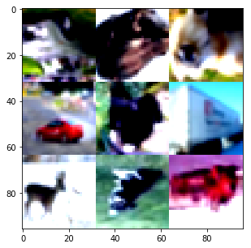

```
Clipping input data to the valid range for imshow with RGB data ([0..1] for floats or [0..255] for integers).
```

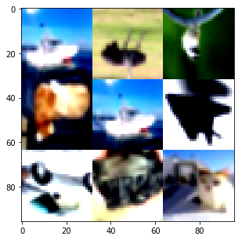

```
Clipping input data to the valid range for imshow with RGB data ([0..1] for floats or [0..255] for integers).
```

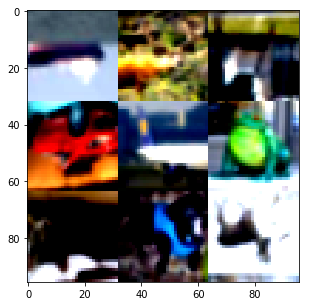

```
Train set: Average loss: 0.2319, Accuracy: 21/140 (15%)
Validation set: Average loss: 0.2316, Accuracy: 2/20 (10%)
New best model built
Epoch: 2
Train set: Average loss: 0.2032, Accuracy: 48/140 (34%)
Validation set: Average loss: 0.2399, Accuracy: 4/20 (20%)
Epoch: 3
Train set: Average loss: 0.1897, Accuracy: 50/140 (36%)
Validation set: Average loss: 0.2304, Accuracy: 4/20 (20%)
New best model built
Epoch: 4
Train set: Average loss: 0.1906, Accuracy: 54/140 (39%)
Validation set: Average loss: 0.2329, Accuracy: 4/20 (20%)
Epoch: 5
Train set: Average loss: 0.1893, Accuracy: 57/140 (41%)
Validation set: Average loss: 0.2408, Accuracy: 4/20 (20%)
Epoch: 6
Train set: Average loss: 0.1910, Accuracy: 54/140 (39%)
Validation set: Average loss: 0.2451, Accuracy: 4/20 (20%)
Epoch: 7
Train set: Average loss: 0.1900, Accuracy: 50/140 (36%)
Validation set: Average loss: 0.2464, Accuracy: 4/20 (20%)
Epoch: 8
Train set: Average loss: 0.1909, Accuracy: 51/140 (36%)
Validation set: Average loss: 0.2509, Accuracy: 6/20 (30%)
Epoch: 9
Train set: Average loss: 0.1947, Accuracy: 44/140 (31%)
Validation set: Average loss: 0.2456, Accuracy: 5/20 (25%)
```

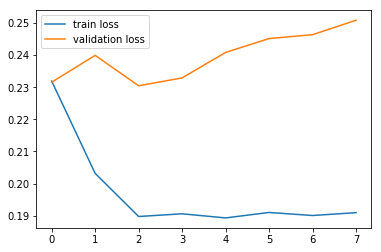

```
Training model on split # 1
Epoch: 1
```

```
Clipping input data to the valid range for imshow with RGB data ([0..1] for floats or [0..255] for integers).
```

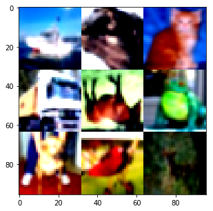

```
Clipping input data to the valid range for imshow with RGB data ([0..1] for floats or [0..255] for integers).
```

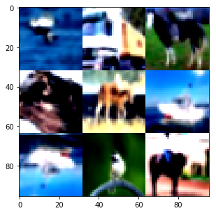

```
Clipping input data to the valid range for imshow with RGB data ([0..1] for floats or [0..255] for integers).
```

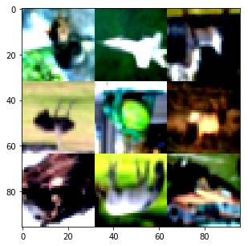

```
Train set: Average loss: 0.2042, Accuracy: 36/140 (26%)
Validation set: Average loss: 0.8256, Accuracy: 2/20 (10%)
New best model built
Epoch: 2
Train set: Average loss: 0.1767, Accuracy: 59/140 (42%)
Validation set: Average loss: 0.2298, Accuracy: 7/20 (35%)
New best model built
Epoch: 3
Train set: Average loss: 0.1728, Accuracy: 61/140 (44%)
Validation set: Average loss: 0.2166, Accuracy: 6/20 (30%)
New best model built
Epoch: 4
Train set: Average loss: 0.1663, Accuracy: 61/140 (44%)
Validation set: Average loss: 0.2139, Accuracy: 6/20 (30%)
New best model built
Epoch: 5
Train set: Average loss: 0.1621, Accuracy: 63/140 (45%)
Validation set: Average loss: 0.2144, Accuracy: 5/20 (25%)
Epoch: 6
Train set: Average loss: 0.1644, Accuracy: 61/140 (44%)
Validation set: Average loss: 0.2120, Accuracy: 5/20 (25%)
New best model built
Epoch: 7
Train set: Average loss: 0.1655, Accuracy: 62/140 (44%)
Validation set: Average loss: 0.2112, Accuracy: 5/20 (25%)
New best model built
Epoch: 8
Train set: Average loss: 0.1681, Accuracy: 62/140 (44%)
Validation set: Average loss: 0.2123, Accuracy: 6/20 (30%)
Epoch: 9
Train set: Average loss: 0.1646, Accuracy: 57/140 (41%)
Validation set: Average loss: 0.2120, Accuracy: 5/20 (25%)
Epoch: 10
Train set: Average loss: 0.1674, Accuracy: 57/140 (41%)
Validation set: Average loss: 0.2127, Accuracy: 5/20 (25%)
```

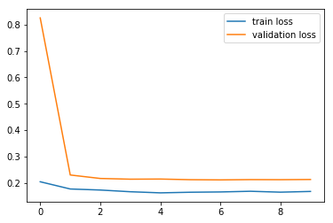

```
Training model on split # 2
Epoch: 1
```

```
Clipping input data to the valid range for imshow with RGB data ([0..1] for floats or [0..255] for integers).
```

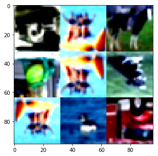

```
Clipping input data to the valid range for imshow with RGB data ([0..1] for floats or [0..255] for integers).
```

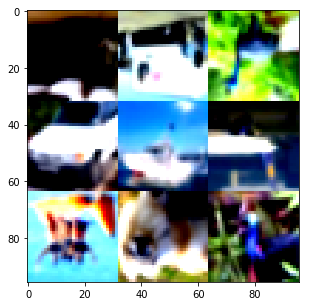

```
Clipping input data to the valid range for imshow with RGB data ([0..1] for floats or [0..255] for integers).
```

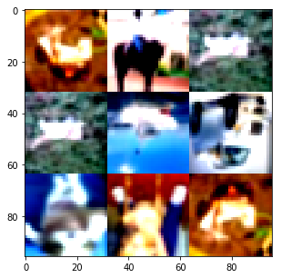

```
Train set: Average loss: 0.1861, Accuracy: 43/140 (31%)
Validation set: Average loss: 0.2915, Accuracy: 3/20 (15%)
New best model built
Epoch: 2
Train set: Average loss: 0.1682, Accuracy: 59/140 (42%)
Validation set: Average loss: 0.2401, Accuracy: 2/20 (10%)
New best model built
Epoch: 3
Train set: Average loss: 0.1556, Accuracy: 70/140 (50%)
Validation set: Average loss: 0.2343, Accuracy: 2/20 (10%)
New best model built
Epoch: 4
Train set: Average loss: 0.1557, Accuracy: 77/140 (55%)
Validation set: Average loss: 0.2328, Accuracy: 3/20 (15%)
New best model built
Epoch: 5
Train set: Average loss: 0.1429, Accuracy: 78/140 (56%)
Validation set: Average loss: 0.2322, Accuracy: 3/20 (15%)
New best model built
Epoch: 6
Train set: Average loss: 0.1505, Accuracy: 68/140 (49%)
Validation set: Average loss: 0.2314, Accuracy: 2/20 (10%)
New best model built
Epoch: 7
Train set: Average loss: 0.1546, Accuracy: 63/140 (45%)
Validation set: Average loss: 0.2340, Accuracy: 4/20 (20%)
Epoch: 8
Train set: Average loss: 0.1523, Accuracy: 71/140 (51%)
Validation set: Average loss: 0.2344, Accuracy: 4/20 (20%)
Epoch: 9
Train set: Average loss: 0.1490, Accuracy: 68/140 (49%)
Validation set: Average loss: 0.2347, Accuracy: 4/20 (20%)
Epoch: 10
Train set: Average loss: 0.1486, Accuracy: 75/140 (54%)
Validation set: Average loss: 0.2296, Accuracy: 3/20 (15%)
New best model built
```

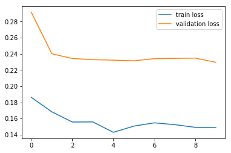

```
Training model on split # 3
Epoch: 1
```

```
Clipping input data to the valid range for imshow with RGB data ([0..1] for floats or [0..255] for integers).
```

[8 more figures not shown]

```
Evaluation on Train Set
Average loss: 0.0140, Accuracy: 57/100 (57%)
Evaluation on Test Set
Average loss: 0.0002, Accuracy: 2139/10000 (21%)
```

```python
resnet = ResNet18()
netClassifierWithDataAugmentationEvaluation(resnet)
```

```
VGG11
Training model on split # 0
Epoch: 1
```

```
Clipping input data to the valid range for imshow with RGB data ([0..1] for floats or [0..255] for integers).
```

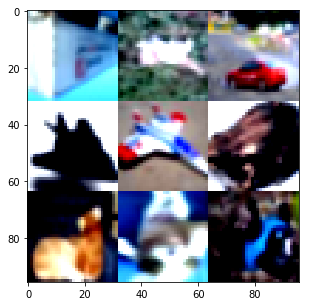

```
Clipping input data to the valid range for imshow with RGB data ([0..1] for floats or [0..255] for integers).
```

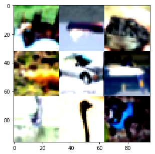

```
Clipping input data to the valid range for imshow with RGB data ([0..1] for floats or [0..255] for integers).
```

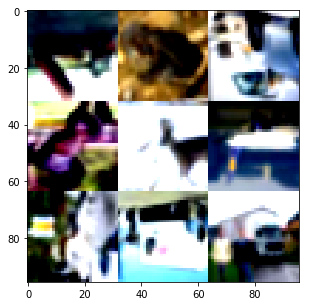

```
Train set: Average loss: 0.2308, Accuracy: 22/140 (16%)
Validation set: Average loss: 0.2308, Accuracy: 2/20 (10%)
New best model built
Epoch: 2
Train set: Average loss: 0.2071, Accuracy: 32/140 (23%)
Validation set: Average loss: 0.2341, Accuracy: 3/20 (15%)
Epoch: 3
Train set: Average loss: 0.1760, Accuracy: 58/140 (41%)
Validation set: Average loss: 0.2307, Accuracy: 5/20 (25%)
New best model built
Epoch: 4
Train set: Average loss: 0.1738, Accuracy: 56/140 (40%)
Validation set: Average loss: 0.2555, Accuracy: 4/20 (20%)
Epoch: 5
Train set: Average loss: 0.1718, Accuracy: 52/140 (37%)
Validation set: Average loss: 0.2628, Accuracy: 3/20 (15%)
Epoch: 6
Train set: Average loss: 0.1790, Accuracy: 58/140 (41%)
Validation set: Average loss: 0.2715, Accuracy: 3/20 (15%)
Epoch: 7
Train set: Average loss: 0.1748, Accuracy: 60/140 (43%)
Validation set: Average loss: 0.2769, Accuracy: 3/20 (15%)
Epoch: 8
Train set: Average loss: 0.1758, Accuracy: 51/140 (36%)
Validation set: Average loss: 0.2713, Accuracy: 3/20 (15%)
Epoch: 9
Train set: Average loss: 0.1781, Accuracy: 50/140 (36%)
Validation set: Average loss: 0.2698, Accuracy: 3/20 (15%)
```

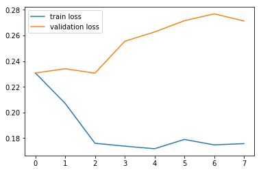

```
Training model on split # 1
Epoch: 1
```

```
Clipping input data to the valid range for imshow with RGB data ([0..1] for floats or [0..255] for integers).
```

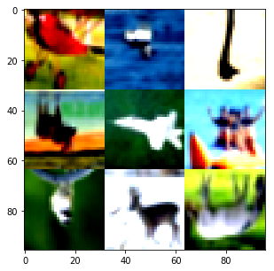

```
Clipping input data to the valid range for imshow with RGB data ([0..1] for floats or [0..255] for integers).
```

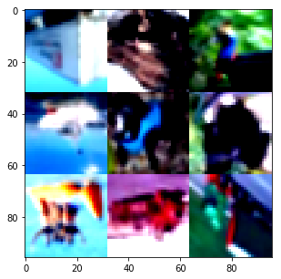

```
Clipping input data to the valid range for imshow with RGB data ([0..1] for floats or [0..255] for integers).
```

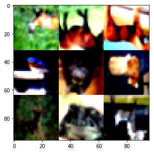

```
Train set: Average loss: 0.2050, Accuracy: 36/140 (26%)
Validation set: Average loss: 0.3103, Accuracy: 5/20 (25%)
New best model built
Epoch: 2
Train set: Average loss: 0.1723, Accuracy: 58/140 (41%)
Validation set: Average loss: 0.2134, Accuracy: 6/20 (30%)
New best model built
Epoch: 3
Train set: Average loss: 0.1473, Accuracy: 74/140 (53%)
Validation set: Average loss: 0.2167, Accuracy: 6/20 (30%)
Epoch: 4
Train set: Average loss: 0.1458, Accuracy: 81/140 (58%)
Validation set: Average loss: 0.2157, Accuracy: 6/20 (30%)
Epoch: 5
Train set: Average loss: 0.1507, Accuracy: 69/140 (49%)
Validation set: Average loss: 0.2246, Accuracy: 6/20 (30%)
Epoch: 6
Train set: Average loss: 0.1425, Accuracy: 84/140 (60%)
Validation set: Average loss: 0.2189, Accuracy: 4/20 (20%)
Epoch: 7
Train set: Average loss: 0.1499, Accuracy: 72/140 (51%)
Validation set: Average loss: 0.2197, Accuracy: 6/20 (30%)
Epoch: 8
Train set: Average loss: 0.1534, Accuracy: 69/140 (49%)
Validation set: Average loss: 0.2228, Accuracy: 5/20 (25%)
```

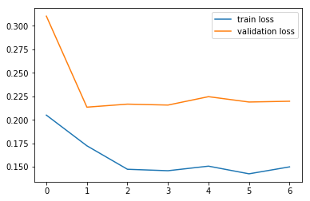

```
Training model on split # 2
Epoch: 1
```

```
Clipping input data to the valid range for imshow with RGB data ([0..1] for floats or [0..255] for integers).
```

[figure not shown]

```
Clipping input data to the valid range for imshow with RGB data ([0..1] for floats or [0..255] for integers).
```

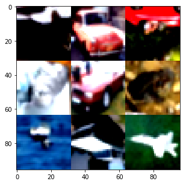

```
Clipping input data to the valid range for imshow with RGB data ([0..1] for floats or [0..255] for integers).
```

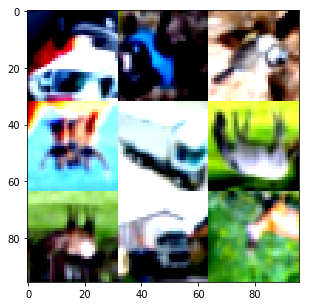

```
Train set: Average loss: 0.1729, Accuracy: 56/140 (40%)
Validation set: Average loss: 0.2995, Accuracy: 4/20 (20%)
New best model built
Epoch: 2
Train set: Average loss: 0.1631, Accuracy: 57/140 (41%)
Validation set: Average loss: 0.2453, Accuracy: 7/20 (35%)
New best model built
Epoch: 3
Train set: Average loss: 0.1393, Accuracy: 71/140 (51%)
Validation set: Average loss: 0.2312, Accuracy: 7/20 (35%)
New best model built
Epoch: 4
Train set: Average loss: 0.1444, Accuracy: 64/140 (46%)
Validation set: Average loss: 0.2288, Accuracy: 8/20 (40%)
New best model built
Epoch: 5
Train set: Average loss: 0.1425, Accuracy: 72/140 (51%)
Validation set: Average loss: 0.2269, Accuracy: 8/20 (40%)
New best model built
Epoch: 6
Train set: Average loss: 0.1360, Accuracy: 79/140 (56%)
Validation set: Average loss: 0.2285, Accuracy: 8/20 (40%)
Epoch: 7
Train set: Average loss: 0.1464, Accuracy: 68/140 (49%)
Validation set: Average loss: 0.2296, Accuracy: 8/20 (40%)
Epoch: 8
Train set: Average loss: 0.1379, Accuracy: 72/140 (51%)
Validation set: Average loss: 0.2279, Accuracy: 8/20 (40%)
Epoch: 9
Train set: Average loss: 0.1400, Accuracy: 72/140 (51%)
Validation set: Average loss: 0.2297, Accuracy: 8/20 (40%)
Epoch: 10
Train set: Average loss: 0.1433, Accuracy: 76/140 (54%)
Validation set: Average loss: 0.2272, Accuracy: 8/20 (40%)
```

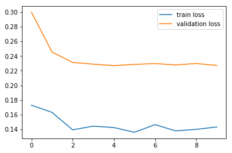

```
Training model on split # 3
Epoch: 1
```

```
Clipping input data to the valid range for imshow with RGB data ([0..1] for floats or [0..255] for integers).
```

[8 more figures not shown]

```
Evaluation on Train Set
Average loss: 0.0138, Accuracy: 52/100 (52%)
Evaluation on Test Set
Average loss: 0.0002, Accuracy: 2263/10000 (23%)
```

```python
for name_net in ['VGG11']:
    print(name_net)
    vggnet = VGG(name_net)
    netClassifierWithDataAugmentationEvaluation(vggnet)
    print("\n")
```

| #Model | Model | Number of epochs | Train accuracy | Test accuracy | Test accuracy on full data *** |
| --- | --- | --- | --- | --- | --- |
| **A** | **TRAINING FROM SCRATCH** | ----- | ------ | ------ | ------ |
| A.1 | ResNet18 | 10 | 91% | 21% | 93.02% (+ with data augmentation) |
| A.2 | VGG11 | 10 | 91% | 24% | XXX |
| **D** | **DATA AUGMENTATION** | ----- | ------ | ------ | ------ |
| D.1 | ResNet18 + data augmentation | 10 | 57%** | 21% | 93.02% |
| D.2 | VGG11 + data augmentation | 10 | 52%** | 23% | XXX |

( ** ) For D.1 ad D.2, what we call "train accuracy" is actually the accuracy on images of the training set to which we applied the data augmentation transform pipeline (this explains the drop in performances).

## Wavelets

**Question 9:** Use a Scattering Transform as an input to a ResNet-like architecture. You can find a baseline here: https://arxiv.org/pdf/1703.08961.pdf.

*Hint:* You can use the following package: https://www.kymat.io/

```python
#I imported this code from https://github.com/edouardoyallon/scalingscattering/blob/master/CIFAR/models/Scatter_WRN.py
#Repository associated to the article https://arxiv.org/pdf/1703.08961.pdf

def conv3x3(in_planes, out_planes, stride=1):
    "3x3 convolution with padding"
    return nn.Conv2d(in_planes, out_planes, kernel_size=3, stride=stride,
                     padding=1, bias=False)

class BasicBlockForScattering(nn.Module):
    expansion = 1

    def __init__(self, inplanes, planes, stride=1, downsample=None):
        super(BasicBlockForScattering, self).__init__()
        self.conv1 = conv3x3(inplanes, planes, stride)
        self.bn1 = nn.BatchNorm2d(planes)
        self.relu = nn.ReLU(inplace=True)
        self.conv2 = conv3x3(planes, planes)
        self.bn2 = nn.BatchNorm2d(planes)
        self.downsample = downsample
        self.stride = stride

    def forward(self, x):
        residual = x

        out = self.conv1(x)
        out = self.bn1(out)
        out = self.relu(out)

        out = self.conv2(out)
        out = self.bn2(out)

        if self.downsample is not None:
            residual = self.downsample(x)

        out += residual
        out = self.relu(out)

        return out

class ResNetForScattering(nn.Module):

    def __init__(self, block,J=2,N=32, k=1,n=2,num_classes=10,use_all=False):
        self.inplanes = 16*k
        self.ichannels = 16*k
        super(ResNetForScattering, self).__init__()
        self.nspace = int(N / (2 ** J))
        self.nfscat = int((1 + 8 * J + 8 * 8 * J * (J - 1) / 2))
        self.bn0 = nn.BatchNorm2d(self.nfscat*3,eps=1e-5,affine=False)
        self.conv1 = nn.Conv2d(self.nfscat*3,self.ichannels, kernel_size=3, stride=1, padding=1,
                               bias=False)
        self.bn1 = nn.BatchNorm2d(self.ichannels)
        self.relu = nn.ReLU(inplace=True)

        self.layer2 = self._make_layer(block, 32*k, n)
        self.layer3 = self._make_layer(block, 64*k, n)
        self.avgpool = nn.AvgPool2d(8)
        self.fc = nn.Linear(64*k, num_classes)

        for m in self.modules():
            if isinstance(m, nn.Conv2d):
                n = m.kernel_size[0] * m.kernel_size[1] * m.out_channels
                m.weight.data.normal_(0, math.sqrt(2. / n))
            elif isinstance(m, nn.BatchNorm2d):
                if m.affine:
                    m.weight.data.fill_(1)
                    m.bias.data.zero_()

    def _make_layer(self, block, planes, blocks, stride=1):
        downsample = None
        if stride != 1 or self.inplanes != planes * block.expansion:
            downsample = nn.Sequential(
                nn.Conv2d(self.inplanes, planes * block.expansion,
                          kernel_size=1, stride=stride, bias=False),
                nn.BatchNorm2d(planes * block.expansion),
            )

        layers = []
        layers.append(block(self.inplanes, planes, stride, downsample))
        self.inplanes = planes * block.expansion
        for i in range(1, blocks):
            layers.append(block(self.inplanes, planes))

        return nn.Sequential(*layers)

    def forward(self, x):
        x = x.view(x.size(0), 3*self.nfscat, self.nspace, self.nspace)
        x = self.bn0(x)

        x = self.conv1(x)
        x = self.bn1(x)
        x = self.relu(x)


        x = self.layer2(x)
        x = self.layer3(x)
        x = self.avgpool(x)
        x = x.view(x.size(0), -1)

        x = self.fc(x)
        return x
```

```python
from keras.layers import Reshape

def resnetClassifierWithScatteringEvaluation(J):

    dataset_train, dataset_val = trainValDatasets[0] #building a unique model based on first split 80/20

    scattering = Scattering2D(J=J, shape=(32, 32))

    transform = transforms.Compose([
        transforms.ToTensor(),
        scattering,
    ])

    transform_train = transform
    transform_test = transform

    ## Network
    net = ResNetForScattering(BasicBlockForScattering,J=J,N=32,k=8,n=2,num_classes=10,use_all=False)
    if use_cuda: net=net.cuda()

    ## Optimization parameters
    net_eval = netClassifierEvaluationObject( dataset_train, dataset_val, transform_train, transform_test, net,
                                          nb_epochs = 10, patience = 5,
                                          batch_size = 10, lr=0.01, momentum = 0.9, viz_data=False)
    net_eval.train(viz=True)

    net_eval.test_eval(testDataSet)
```

```
Epoch: 1
Train set: Average loss: 0.2385, Accuracy: 27/140 (19%)
Validation set: Average loss: 0.2688, Accuracy: 2/20 (10%)
New best model built
Epoch: 2
Train set: Average loss: 0.1415, Accuracy: 83/140 (59%)
Validation set: Average loss: 0.2841, Accuracy: 1/20 (5%)
Epoch: 3
Train set: Average loss: 0.1163, Accuracy: 111/140 (79%)
Validation set: Average loss: 0.2854, Accuracy: 2/20 (10%)
Epoch: 4
Train set: Average loss: 0.1167, Accuracy: 105/140 (75%)
Validation set: Average loss: 0.2800, Accuracy: 2/20 (10%)
Epoch: 5
Train set: Average loss: 0.1143, Accuracy: 109/140 (78%)
Validation set: Average loss: 0.2658, Accuracy: 2/20 (10%)
New best model built
Epoch: 6
Train set: Average loss: 0.1196, Accuracy: 103/140 (74%)
Validation set: Average loss: 0.2357, Accuracy: 3/20 (15%)
New best model built
Epoch: 7
Train set: Average loss: 0.1166, Accuracy: 105/140 (75%)
Validation set: Average loss: 0.2083, Accuracy: 4/20 (20%)
New best model built
Epoch: 8
Train set: Average loss: 0.1136, Accuracy: 107/140 (76%)
Validation set: Average loss: 0.1947, Accuracy: 4/20 (20%)
New best model built
Epoch: 9
Train set: Average loss: 0.1140, Accuracy: 113/140 (81%)
Validation set: Average loss: 0.1925, Accuracy: 5/20 (25%)
New best model built
Epoch: 10
Train set: Average loss: 0.1124, Accuracy: 111/140 (79%)
Validation set: Average loss: 0.1914, Accuracy: 5/20 (25%)
New best model built
```

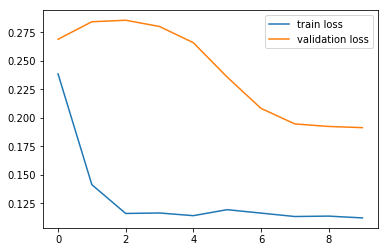

```
Average loss: 0.2107, Accuracy: 2678/10000 (27%)
```

```python
J=2
resnetClassifierWithScatteringEvaluation(J)
```

| #Model | Model | Number of epochs | Train accuracy | Test accuracy | Test accuracy on full data *** |
| --- | --- | --- | --- | --- | --- |
| **A** | **TRAINING FROM SCRATCH** | ----- | ------ | ------ | ------ |
| A.1 | ResNet18 | 10 | 91% | 21% | 93.02% (+ with data augmentation) |
| **B** | **TRANSFER LEARNING** | ----- | ------ | ------ | ------ |
| B.1 | ResNet18 pretrained (no finetuning) | 10 | 98% | 54% | XXX |
| B.2 | ResNet18 pretrained (finetuning) | 10 | 100% | 51% | XXX |
| **D** | **DATA AUGMENTATION** | ----- | ------ | ------ | ------ |
| D.1 | ResNet18 + data augmentation | 10 | 57%** | 21% | 93.02% |
| **E** | **SCATTERING TRANSFORM** | ----- | ------ | ------ | ------ |
| E.1 | ResNet18 + scattering transform | 10 | 79% | 27% | 93.1% |

( ** ) For D.1 ad D.2, what we call "train accuracy" is actually the accuracy on images of the training set to which we applied the data augmentation transform pipeline (this explains the drop in performances).

( *** ) Sources for the last column :

- https://github.com/kuangliu/pytorch-cifar for A.1. and A.4.
- https://arxiv.org/pdf/1703.08961.pdf for C.1 and E.1. This article also provides 34.7% and 38.9% for A.1 and E.1 respectively for a training set of 100 samples.

# Weak supervision

Weakly supervised techniques permit to tackle the issue of labeled data. An introduction to those techniques can be found here: https://hazyresearch.github.io/snorkel/blog/ws_blog_post.html.

**(Open) Question 10:** Pick a weakly supervised method that will potentially use $\mathcal{X}\cup\mathcal{X}_{\text{train}}$ to train a representation (a subset of $\mathcal{X}$ is also fine). Evaluate it and report the accuracies. You should be careful in the choice of your method, in order to avoid heavy computational effort.

```python
#Below is a predictor of targets distributions (vectors with the probability to belong to each class)
#thanks to the ResNet18 network pre-trained on ImageNet and soft_cross_entropy loss criterion (cross_entropy for targets which are distributions)
#this class is very similar to netClassifierEvaluationObject
#(only the loss criterion differ, and some type conversion of targets, as these are now vector of floats)

def soft_cross_entropy(pred, soft_targets):
    logsoftmax = nn.LogSoftmax()
    return torch.mean(torch.sum(- soft_targets * logsoftmax(pred), 1))

class softLabelsPredictor():

    def __init__(self, train_dataset, val_dataset, transform,
                 nb_epochs = 10, patience = 10, batch_size=10, lr=0.1, momentum = 0.9,  nb_epochs_decay=30):
        # parameters explained at the top of the cell

        #Data Loader
        train_dataset.transform = transform
        self.train_loader = torch.utils.data.DataLoader(train_dataset, batch_size=batch_size, shuffle=True, num_workers=1)

        val_dataset.transform = transform
        self.val_loader = torch.utils.data.DataLoader(val_dataset, batch_size=batch_size, shuffle=False, num_workers=1)
        self.transform = transform

        #Network
        self.net = pretrainedResnet18(fine_tuning=False)
        if use_cuda: self.net = self.net.cuda()
        self.criterion = soft_cross_entropy

        #Optimizer
        self.optimizer = optim.SGD(self.net.parameters(), lr=lr, momentum=momentum) #0.9)
        self.nb_epochs = nb_epochs
        self.patience = patience
        self.nb_epochs_decay = nb_epochs_decay
        self.batch_size = batch_size

    def train_epoch(self, epoch):
        #train the network for a given epoch

        print('Epoch: %d' % epoch)
        self.net.train()
        train_loss = 0
        correct = 0
        total = 0
        for batch_idx, (inputs, targets) in enumerate(self.train_loader):
            inputs, targets = inputs.to(device), targets.to(device) #.long()
            self.optimizer.zero_grad()
            outputs = self.net(inputs.float())
            loss = self.criterion(outputs, targets.float())
            loss.backward()
            self.optimizer.step()

            train_loss += loss.item()
            _, predicted = outputs.max(1)
            total += targets.size(0)
            _, max_targets = targets.max(1)
            correct += predicted.eq(max_targets).sum().item()

        acc = 100. * correct / total
        train_loss /= total
        print('Train set: Average loss: {:.4f}, Accuracy: {}/{} ({:.0f}%)'.format(
                train_loss, correct, total, acc))
        return acc, train_loss

    def val_epoch(self, epoch):
        #assess the network on the validation set at the end of a given epoch

        self.net.eval()
        test_loss = 0
        correct = 0
        total = 0
        with torch.no_grad():
            for batch_idx, (inputs, targets) in enumerate(self.val_loader):
                inputs, targets = inputs.to(device), targets.to(device)
                outputs = self.net(inputs.float())
                loss = self.criterion(outputs, targets.float())

                test_loss += loss.item()
                _, predicted = outputs.max(1)
                total += targets.size(0)
                _, max_targets = targets.max(1)
                correct += predicted.eq(max_targets).sum().item()

        acc = 100. * correct / total
        test_loss /= total
        print('Validation set: Average loss: {:.4f}, Accuracy: {}/{} ({:.0f}%)'.format(
            test_loss, correct, total, acc))
        return acc, test_loss

    def train(self, viz=False):
        #train the network
        #if viz=True, vizualisation of train/val loss evolutions curbs at the end of the training

        train_losses = []
        val_losses = []
        best_loss = math.inf
        cpt_increases_loss = 0


        best_weights = self.net.state_dict()

        for epoch in range(1, self.nb_epochs + 1):

            train_acc, train_loss = self.train_epoch(epoch)
            val_acc, val_loss = self.val_epoch(epoch)

            if epoch>1 and val_loss > best_loss:
                cpt_increases_loss += 1
                if cpt_increases_loss > self.patience: break

            else:
                if val_loss < best_loss:
                    cpt_increases_loss = 0
                    best_loss = val_loss
                    print("New best model built")
                    best_weights = self.net.state_dict()

            train_losses.append(train_loss)
            val_losses.append(val_loss)

            if epoch % (self.nb_epochs_decay):
                state_dict = self.optimizer.state_dict()
                for param_group in state_dict['param_groups']:
                    param_group['lr'] /= 10.
                self.optimizer.load_state_dict(state_dict)

        self.net.load_state_dict(best_weights)

        if viz:
            epochs = list(range(len(train_losses)))
            plt.plot(epochs, train_losses, label = "train loss")
            plt.plot(epochs, val_losses, label = "validation loss")
            plt.legend()
            plt.show()

    def test_eval(self, testDataSet, vector_targets = True):
        #assess the network on a test dataset : print loss and accuracy

        testDataSet.transform = self.transform
        test_loader = torch.utils.data.DataLoader(testDataSet, batch_size=self.batch_size, shuffle=False, num_workers=1)

        self.net.eval()
        test_loss = 0
        correct = 0
        total = 0
        with torch.no_grad():
            for batch_idx, (inputs, targets) in enumerate(test_loader):
                inputs, targets = inputs.to(device), targets.to(device)
                outputs = self.net(inputs)
                loss = self.criterion(outputs, targets.float())

                test_loss += loss.item()
                _, predicted = outputs.max(1)
                total += targets.size(0)
                if vector_targets:
                    _, max_targets = targets.max(1)
                else:
                    max_targets = targets
                correct += predicted.eq(max_targets).sum().item()

        acc = 100. * correct / total
        test_loss /= total
        print('Average loss: {:.4f}, Accuracy: {}/{} ({:.0f}%)'.format(
            test_loss, correct, total, acc))
        return acc, test_loss
```

```python
from sklearn.neighbors import KNeighborsClassifier
from keras.utils import to_categorical

#I implement in this cell a weakly supervised method :
#Probabilities to belong to each class are the outputs of a resNet-18 architecture
#where the targets are :
#-For labelled data : One-hot encoding of true labels
#-For unlabelled data : Probabilities given by a Nearest Neighbor Classifier
#on the GAN discriminator representations (which are built using all train data (labelled + unlabelled))

class GAN_kNN():
    #a kNN classifier built on the top of GAN embeddings
    #enabling to assign weak labels to unlabelled data

    def __init__(self, dataset_train, dataset_val):

        input_size = 32
        self.transform = transforms.Compose([
            transforms.Resize((input_size,input_size)),
            transforms.ToTensor(),
            transforms.Normalize((0.4914, 0.4822, 0.4465), (0.2023, 0.1994, 0.2010)),
        ])

        transform_train = self.transform
        transform_test = self.transform

        netG = Generator(nc=3, nz=100, ngf=64).to(device)
        netD = Discriminator(nc=3, ndf=64).to(device)

        self.batchsize = 10
        self.GAN_eval = GAN_SVM_EvaluationObject(dataset_train, dataset_val,
                                                 transform_train, transform_test,
                                                 netG, netD,
                                                 nb_epochs = 10, patience = 5, batch_size=self.batchsize, lr=0.01,
                                                 shuffle_train=False, shuffle_val=False)

         # we use weights of a GAN pre-trained on CIFAR training dataset
        self.GAN_eval.load_weights_GAN("GAN_weights/netG_epoch_199.pth","GAN_weights/netD_epoch_199.pth")

    def get_weak_labels(self, n_neighbors=10, max_unlabelled=1000, viz=True): #directly on GAN, or on PCA ??

        # getting GAN embeddings of training labelled data, and of validation data
        embeddings_train, targets_train =  self.GAN_eval.get_GAN_embeddings(self.GAN_eval.train_loader)
        embeddings_val, targets_val = self.GAN_eval.get_GAN_embeddings(self.GAN_eval.val_loader)

        # building a kNN trained on the GAN embeddings of training labelled data
        # selecting k with validation data

        if n_neighbors is None:
            list_n = [(k+1)*5 for k in range(20)]
            scores = []
            for n in list_n:
                knn = KNeighborsClassifier(n_neighbors=n)
                knn.fit(embeddings_train, targets_train)
                score = knn.score(embeddings_val, targets_val)
                scores.append(score)
            if viz:
                plt.scatter(list_n, scores)
                plt.xlabel("number of nearest neighbors"); plt.ylabel("validation score")
                plt.show()
            n_neighbors = list_n[np.argmax(scores)]
            print("select number of nearest neighbors : ", n_neighbors)

        self.knn = KNeighborsClassifier(n_neighbors=n_neighbors)
        self.knn.fit(embeddings_train, targets_train)
        #print("Train set score: ",self.knn.score(embeddings_train, targets_train))
        #print("Validation set score: ",self.knn.score(embeddings_val, targets_val))

        # getting GAN embeddings of unlabelled data
        subsetUnlabelledDataSet  = CIFAR10("./", known_targets = False, download=False, train=True,
                                           min_idx_images = 100, nb_images =  max_unlabelled, verbose=False)
        subsetUnlabelledDataSet.transform = self.transform
        data_loader = torch.utils.data.DataLoader(subsetUnlabelledDataSet, batch_size=self.batchsize, shuffle=False, num_workers=1)
        embeddings_unlabelled, unknown_labels = self.GAN_eval.get_GAN_embeddings(data_loader)

        #embeddings and weak labels of unlabelled data
        embeddings_unlabelled = embeddings_unlabelled
        weak_targets_unlabelled = self.knn.predict_proba(embeddings_unlabelled)

        #gathering all data and labels (true labels for labelled, weak labels for unlabelled)
        all_data_train = np.vstack([dataset_train.data, subsetUnlabelledDataSet.data])
        targets_train = to_categorical(targets_train, num_classes=10)
        all_targets_train = np.vstack([targets_train, weak_targets_unlabelled])
        print("shapes embeddings and targets",all_data_train.shape,all_targets_train.shape)

        #saving also data_val, targets_val for validation set of  soft labels predictor
        data_val = dataset_val.data
        targets_val = to_categorical(targets_val, num_classes=10)

        return all_data_train, all_targets_train, data_val, targets_val

def resnet18Classifier_With_GAN_kNN_WeakLabels_Evaluation(soft_labels = True):

    ##If soft_labels is True
    #Targets for the resNet-18 architecture are :
    #-For labelled data : One-hot encoding of true labels
    #-For unlabelled data : Probabilities given by a Nearest Neighbor Classifier
    #on the GAN discriminator representations (which are built using all train data (labelled + unlabelled))

    ##If soft_labels is False
    #Targets for the resNet-18 architecture are :
    #-For labelled data : true labels
    #-For unlabelled data : label given by a Nearest Neighbor Classifier
    #on the GAN discriminator representations (which are built using all train data (labelled + unlabelled))

    #Important note :  we use weights of a GAN pre-trained on CIFAR training dataset
    #To be able to run this cell,one need to download the two files "netG_epoch_199.pth","netD_epoch_199.pth"
    #in the following Git repository https://github.com/csinva/pytorch_gan_pretrained/tree/master/cifar10_dcgan/weights
    #and to put the two files in a folder named "GAN_weights"

    #1. Getting WEAK LABELS of labelled data
    dataset_train, dataset_val = trainValDatasets[0] #building a unique model based on the first split 80/20
    max_unlabelled=100
    gan_knn = GAN_kNN(dataset_train, dataset_val)
    #all_data_train will contain both the 80% of labelled data and the selection subset of unlabelled data
    #targets_train are the corresponding soft labels (probability distributions over labels)
    #data_val is the 20% remaining of labelled data, and targets_val their labels one hot encoding
    all_data_train, all_targets_train, data_val, targets_val = gan_knn.get_weak_labels(n_neighbors=None,
                                                                                   max_unlabelled=max_unlabelled,
                                                                                   viz=False)
    #2. Building a predictor of SOFT/HARD LABELS with pre-trained resnet18

    transform = transforms.Compose([
        transforms.Resize((224,224)),
        transforms.ToTensor(),
        transforms.Normalize((0.4914, 0.4822, 0.4465), (0.2023, 0.1994, 0.2010)),
    ])

    if soft_labels: #using WEAK SOFT labels of unlabelled data

        all_train_dataset = Dataset(all_data_train, all_targets_train)
        val_dataset = Dataset(data_val, targets_val)

        #Building the predictor
        net_eval = softLabelsPredictor(all_train_dataset, val_dataset,
                                   transform, nb_epochs = 10, patience = 5, batch_size=10, lr=0.01, momentum = 0.9)
        net_eval.train(viz=True)

        #Assessing the predictor
        print("\n")
        print("Evaluation on Train Set")
        net_eval.test_eval(all_train_dataset, vector_targets = True)
        print("Evaluation on Test Set")
        net_eval.test_eval(testDataSet, vector_targets = False)

    else:  #using WEAK HARD labels of unlabelled data
        all_targets_train = np.argmax(all_targets_train,axis=1)
        targets_val = np.argmax(targets_val,axis=1)

        all_train_dataset = Dataset(all_data_train, all_targets_train)
        val_dataset = Dataset(data_val, targets_val)

        net = pretrainedResnet18(fine_tuning=False)

        net_eval = netClassifierEvaluationObject(all_train_dataset, val_dataset, transform, transform, net,
                 nb_epochs = 10, patience = 5, batch_size=10, lr=0.01, momentum = 0.9)
        net_eval.train(viz=True)

        #Assessing the predictor
        print("\n")
        print("Evaluation on Train Set")
        net_eval.test_eval(all_train_dataset)
        print("Evaluation on Test Set")
        net_eval.test_eval(testDataSet)
```

```
select number of nearest neighbors :  55
shapes embeddings and targets (240, 32, 32, 3) (240, 10)
Epoch: 1
Train set: Average loss: 0.2942, Accuracy: 44/240 (18%)
Validation set: Average loss: 0.2656, Accuracy: 2/20 (10%)
New best model built
Epoch: 2
Train set: Average loss: 0.1545, Accuracy: 119/240 (50%)
Validation set: Average loss: 0.2296, Accuracy: 4/20 (20%)
New best model built
Epoch: 3
Train set: Average loss: 0.1344, Accuracy: 129/240 (54%)
Validation set: Average loss: 0.2293, Accuracy: 4/20 (20%)
New best model built
Epoch: 4
Train set: Average loss: 0.1298, Accuracy: 139/240 (58%)
Validation set: Average loss: 0.2251, Accuracy: 4/20 (20%)
New best model built
Epoch: 5
Train set: Average loss: 0.1327, Accuracy: 134/240 (56%)
Validation set: Average loss: 0.2293, Accuracy: 4/20 (20%)
Epoch: 6
Train set: Average loss: 0.1335, Accuracy: 136/240 (57%)
Validation set: Average loss: 0.2263, Accuracy: 4/20 (20%)
Epoch: 7
Train set: Average loss: 0.1298, Accuracy: 143/240 (60%)
Validation set: Average loss: 0.2259, Accuracy: 4/20 (20%)
Epoch: 8
Train set: Average loss: 0.1305, Accuracy: 139/240 (58%)
Validation set: Average loss: 0.2310, Accuracy: 3/20 (15%)
Epoch: 9
Train set: Average loss: 0.1275, Accuracy: 141/240 (59%)
Validation set: Average loss: 0.2264, Accuracy: 4/20 (20%)
Epoch: 10
Train set: Average loss: 0.1306, Accuracy: 140/240 (58%)
Validation set: Average loss: 0.2288, Accuracy: 3/20 (15%)
```

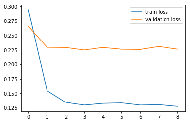

```
Evaluation on Train Set
Average loss: 0.1168, Accuracy: 147/240 (61%)
Evaluation on Test Set
Average loss: 0.2175, Accuracy: 2336/10000 (23%)
```

```python
#resnet18Classifier_With_GAN_kNN_WeakLabels_Evaluation(soft_labels = True)
resnet18Classifier_With_GAN_kNN_WeakLabels_Evaluation(soft_labels = False)

#using weak soft labels lead to even worse results than using weak hard labels of unlabelled data ...
```

| #Model | Model | Number of epochs | Train accuracy | Test accuracy | Test accuracy on full data *** |
| --- | --- | --- | --- | --- | --- |
| **A** | **TRAINING FROM SCRATCH** | ----- | ------ | ------ | ------ |
| A.1 | ResNet18 | 10 | 91% | 21% | 93.02% (+ with data augmentation) |
| **B** | **TRANSFER LEARNING** | ----- | ------ | ------ | ------ |
| B.1 | ResNet18 pretrained (no finetuning) | 10 | 98% | 54% | XXX |
| **C** | **SEMI-SUPERVISED LEARNING** | ----- | ------ | ------ | ------ |
| C.1 | GAN pretrained + SVM | Not adequate (pre-training) | 100% | 30% | 82.8% |
| **F** | **WEAKLY-SUPERVISED LEARNING** | ----- | ------ | ------ | ------ |
| F.1 | GAN pretrained + Weak Labels from kNN on DCGAN features + ResNet18 | 10 | 61%** | 23% | XXX |

# Conclusions

**Question 11:** Write a short report explaining the pros and the cons of each methods that you implemented. 25% of the grade of this project will correspond to this question, thus, it should be done carefully. In particular, please add a plot that will summarize all your numerical results.

**Report**

> In part 1, I remind the context as well as an important assumption I made in this TP.

> In part 2, I remind the two solutions I proposed to get a more reliable training procedure evaluation (question 2).

> In part 3, I study the pros and the cons of each method I implemented and experienced with.

> In part 4, I discuss the obtained results and the possible paths of improvement.

> Table summarizing the results is given at the bottom of this Jupyter Notebook.

**1. Context**

> The goal of this practical was to train a supervised model using only $X_{train}$, the first 100 examples of the CIFAR10 training dataset. To develop the model, we could also dispose of $X$, the remaining 49900 samples of the CIFAR10 training set, but for which we hide the labels.

> I assumed that we were not allowed to see $X_{test}$, the 10000 samples of CIFAR10 test set, when developping the model : thus we had to build our validation sets picking instances exclusively from the 100 first instances.

**2. Solutions for a better training procedure evaluation question**

*Note : this part is essentially a repetition of my answer to question 2/11.*

**2.1. How to deal with the small size of the labelled training set for validation ?**

> In order to know when to stop the training (and to tune the hyperparameters), we need to split $X_{train}$ into a training dataset $D_{train}$ and a validation dataset $D_{val}$. As $|X_{train}|=100$, we are torn apart between keeping a large proportion of images in $X_{train}$ to predict better, and having a reasonably large $D_{val}$ to assess correctly the prediction accuracy of our model at a given time of the training.

**2.2. How to deal with the unbalanced classes in the labelled training set ?**

> In addition, the number of examples per class in $X_{train}$ varies much between classes in $X_{train}$ (16 examples for the largest class, 4 for the smallest). If we have a unbalanced set $D_{train}$, this is prone to lead to bias in the predictions. While if $D_{val}$ is unbalanced, our model assessment will not be reliable.

> To ensure that the training set and that the validation set are balanced : 1) I first built the validation set $D_{val}$, by picking at random two examples per class. 2) Then, to ensure the training set $D_{train}$ in balanced, I replicated $\max_{0 \leq j \leq 9} |C_j| -|C_i|$ examples from class $C_i$, where $|C|$ denotes the number of examples in class $C$ in $D_{train}$. I preferred oversampling the smallest classes (adding replicated examples) to undersampling the largest classes (remvoving examples) as our training set is already very small. Another solution to remove the bias could have consisted in dividing the model output probabilities of belonging to each class by the prior probabilites (ie. the number of instances per class in the training set).

**3. Methods, results, pros and cons**

**3.1. Training CNNs (ResNet, VGG) from scratch**

First method we considered is to train Convolutional Neural Networks from scratch, ie. begininning with a random initialization of the weights and using only instances from $D_{train}$ for training.

We tried two types of CNN :

- ResNet-18, a residual network with 18 layers.
- VGG, which essentially uses 3×3 convolutional layers stacked on top of each other, with max-pooling layers reducing volume size with depth increasing. We tried different architectures/depths for VGG, with 11, 13, 16 and 19 layers.

I optimized the weights thanks to Stochastic Gradient Descent, using a learning rate of 0.01, a momentum of 0.9, and fixing the maximum number of epochs to 10 (with early stopping policy : stop after 5 epochs without decrease of the validation loss, and we kept the weights associated to the lowest validation loss for predictions).

**3.2. Transfer learning (without and with finetuning)**

We then considered the transfer learning strategy. I resized the images from $32*32$ to $224*224$ and used a ResNet-18 architecture whose weights were already learnt on the ImageNet database.

More precisely, I considered two strategies :

- 1) extract the images representations at the penultimate layer of the pre-trained network, and learn a simple classifier on these representations. This strategy simply amounts to changing the output dimension of the last linear layer of the original ResNet (for 10 output classes), and learn its weights with $D_{train}$ while freezing the weights of any other layer.
- 2) fine-tune a part of a the pre-trained ResNet, from the top layer (with output dimension modified) up to the deepest layer of the network that my memory would enable me to (again by freezing all the weights upstream). I chose to privilege the highest layers for the fine-tuning as these are expected to learn the more specialized features, hence this is where we could gain the most for our specialized classification on CIFAR10. More precisely, I could finetune ResNet-18 from the 10th layer, ie. the two highest ResNet blocks, each of them composed of 2 convolutional layers with residual connections (256 maps with kernel size $3*3$, and 512 maps with kernel size $3*3$ respectively)

> **Results / Pros / Cons** :
> - Transfer learning is very interesting here given the very small size of the training set and given the same type of objects featured by CIFAR10 and by ImageNet (on which was pre-trained the ResNet architecture we used). The features captured by the first layers of CNNs are always low-level and universal, but here we can even expect that the mid-level representations learnt on ImageNet are also interesting for our CIFAR10 classification task.
> - Strategy 1) (no-finetuning, linear classifier on the top of pre-trained embeddings) costs very little in terms of ressources. And it definitely improved the accuracies, compared to training the small ResNet-18 from scratch (from 21% to 54% in test accuracy).
> - Strategy 2), in which we additionnally finetuned the weights of the deepest layers (expected to learn the more specialized features), costs of course more but may appear more appealing in terms of accuracy. However, it did not improve performances in our experiments (only 51% in test accuracy). It is quite suprising, though we guess performances could be improved using a better optimization scheme and more epochs.
> - Finally, one hypothesis to explain the performances barrier of around 50% using transfer learning is that the resolutions of the CIFAR10 images and of the ResNet-18 are very different. One potentially interesting strategy to deal with that could consist in zooming/blurring the ImageNet images and pre-training the architecture with such blurred images (or, equivalently, reducing the size of the ImageNet images and pre-training the ResNet-18 architecture adequate for $32*32$ images used in question 3).

**3.3. Semi-Supervised Learning : DCGAN features + Linear Classifier**

Third method I used consists in learning a classifier, here a Support Vector Machine (with linear kernel), on the top of the embeddings learnt by the Discriminator of a GAN.

This is a Semi-Supervised Method as we do not make use only of the 100 labelled instances of $X_{train}$, but also of the unlabelled instances of $X$ to learn the unsupervised GAN Discriminator representations.

The chosen GAN architecture is caracterized by a noise dimension of 100 (space from which are generated the synthetic images) and by a discriminator embedding of dimension $64*8*2*2 = 2048$ (on which is applied the last convolutional layer and sigmoid for classification "real/synthetic").

I allowed two possibilities in the code:

- either learning the weights of the GAN using a portion of the unlabelled examples $X$
- or loading the pre-trained weights of the GAN on CIFAR training set (imported from https://github.com/csinva/pytorch_gan_pretrained/tree/master/cifar10_dcgan/weights). In the end I worked only with option (b) given our limited ressources.

I then computed the DCGAN features (discriminator embeddings) for all training labelled data, and learnt the Multi-Class SVM according to a One-Versus-Rest scheme, choosing the regularization weight C (penalty of an outlier) based on a log-scale grid search with simple validation.

> **Results / Pros / Cons** :

> This approach led to a better accuracy (30%) than training from scratch supervised CNN architectures (21-24%).

> Learning an unsupervised representation of the images (thanks to the GAN Discriminator here) is definitely interesting as it allows to make a good use of unlabelled data.

> However, training a GAN is a difficult task (cf. TP1 on Generative Modelling), and making it converge requires ressources. I did not succeed in this task, and that's why I used in the end an already pre-trained GAN on CIFAR training set.

**3.4. Data Augmentation**

Next strategy we tried consists in increasing the size of the training dataset, using various data augmentation strategies.

I applied at random various transformations "on the fly" to the selected batches. I tried:

- translations and scalings with various zooms
- rotations with angles in {0°, 90°, 180°, 270°}
- color changes (brightness/contrast)
- adding noise (gaussian blur and salt-and-pepper)

> **Results / Pros / Cons** :

> The data augmentation strategies I tried did not increase the accuracy, within the same number of epochs.

> However, it theoretically remains an interesting strategy to reduce overfitting on larger architectures, with more capacity, provided that we have the computing ressources to train such deep networks. These transformed data indeed helps the network to learn useful invariances.

> Last, combining transfer learning with data augmentation on ImageNet images, applying strong blur for instance, would have maybe been more relevant here (given the low resolution of CIFAR10 images).

**3.5. Using Scattering Transform**

Next, I tried applying the Scattering Transform to the training images and used the ResNet architecture described in https://arxiv.org/pdf/1703.08961.pdf appropriate for the new input.

> **Results / Pros / Cons** :

> Contrary to the data augmentation strategies defined in 3.4, applying the Scattering Transform led to an increase in test accuracy (from 21% to 27%). There are certainly much more investigations to do regarding parameters tuning and optimizers, since the article reported 38% accuracy using a CIFAR training set of 100 images.

> The Scattering Transform is helpful, as it incoporates geometrical invariants in an unsupervised way. As we do not know all sources of variabilities for CIFAR natural images, the Scattering Transfrom should potentially help the network to learn richer invariances than the ones we manually defined in 3.4.

**3.6. Weakly-Supervised Learning : Weak Labels from kNN on DCGAN features + ResNet Predictor of Weak Labels**

The Weakly Supervised Learning strategy I implemented is the following :

I first trained a Nearest-Neighbor classifier based on the DCGAN features to get weak labels for the unlabelled data, ie. an estimated probability for each unlabelled data to belong to each class. I selected the number of nearest neighbors with simple validation.

I then considered two options to train a ResNet-18 architecture :

2) or we predict the hard labels : true labels of labelled data, and most likely labels of unlabelled data

> **Results / Pros / Cons** :

> Both strategies hurted a lot the performances, even adding only 100 unlabelled data to the 100 training labelled data. To make better use of the unlabelled data, it would have been maybe more fruitful to infer weak labels from a better unsupervised representation than DCGAN features.

**4. Results summary with table**

> In conclusion, it appears first that, on this very small training dataset, **Transfer Learning** leads to the highest gain in accuracy (with respect to training CNN from scratch) and without much effort. However, fine-tuning was not of precious help here. Last, we think that performances could have been even increased if pre-training a ResNet with blurred/smaller ImageNet images (to get closer to the CIFAR10 resolution).

> **Semi-Supervised Learning**, which consisted here in learning an SVM classifier on the top of DCGAN unsupervised representation, appears as the second most promising solution (given the very large size of the unlabelled dataset $X$).

> Our experiments with **Scattering Transform** showed a gain in accuracy (but not as important as the one we could have expected according to https://arxiv.org/pdf/1703.08961.pdf). Unsupervised incorporation of geometrical invariants was definitely more efficient than supervised **Data Augmentation** which did not enhance performances.

> Finally, **Weakly-Supervised Learning** was not succesfull. Having better unsupervised representations than DCGAN features to assign better weak labels for unlabelled data would have been useful.

| #Model | Model | Number of epochs* | Train accuracy | Test accuracy | Test accuracy on full data *** |
| --- | --- | --- | --- | --- | --- |
| **A** | **TRAINING FROM SCRATCH** | ----- | ------ | ------ | ------ |
| A.1 | ResNet18 | 10 | 91% | 21% | 93.02% (+ with data augmentation) |
| A.2 | VGG11 | 10 | 91% | 24% | XXX |
| A.3 | VGG13 | 10 | 69% | 22% | XXX |
| A.4 | VGG16 | 10 | 15% | 11% | 92.64% (+ with data augmentation) |
| A.5 | VGG19 | 10 | 15% | 13% | XXX |
| **B** | **TRANSFER LEARNING** | ----- | ------ | ------ | ------ |
| B.1 | ResNet18 pretrained (no finetuning) | 10 | 98% | 54% | XXX |
| B.2 | ResNet18 pretrained (finetuning) | 10 | 100% | 51% | XXX |
| **C** | **SEMI-SUPERVISED LEARNING** | ----- | ------ | ------ | ------ |
| C.1 | GAN pretrained + SVM | Not adequate (pre-training) | 100% | 30% | 82.8% |
| **D** | **DATA AUGMENTATION** | ----- | ------ | ------ | ------ |
| D.1 | ResNet18 + data augmentation | 10 | 57%** | 21% | 93.02% |
| D.2 | VGG11 + data augmentation | 10 | 52%** | 23% | XXX |
| **E** | **SCATTERING TRANSFORM** | ----- | ------ | ------ | ------ |
| E.1 | ResNet18 + scattering transform | 10 | 79% | 27% | 93.1% |
| **F** | **WEAKLY-SUPERVISED LEARNING** | ----- | ------ | ------ | ------ |
| F.1 | GAN pretrained + Weak Labels from kNN on DCGAN features + ResNet18 | 10 | 61%** | 23% | XXX |

( * ) Number of epochs means maximum number of epochs (early stopping policy, and we keep the best weights found).

( ** ) For D.1 ad D.2, what we call "train accuracy" is actually the accuracy on images of the training set to which we applied the data augmentation transform pipeline (this explains the drop in performances). For F.1, what we call "train accuracy" is the accuracy on both the labelled images and the unlabelled ones which were used for the training of the final prediction model (assigning for the unlabelled images the most likely labels for the GAN-kNN).

( *** ) Sources for the last column :

- https://github.com/kuangliu/pytorch-cifar for A.1. and A.4.
- https://arxiv.org/pdf/1703.08961.pdf for C.1 and E.1. This article also provides 34.7% and 38.9% for A.1 and E.1 respectively for a training set of 100 samples.